# **HomeWork 2- Titanic: Machine Learning from disaster**

**submmit:** Iris Grabov & Shay Gelbart

https://www.kaggle.com/irisgrabov

**About the task:**

The Titanic dataset task is a foundational machine learning problem where you predict the survival of passengers aboard the Titanic based on provided features such as age, gender, ticket class, family relationships, and fare. The training dataset includes the "Survived" column (the target variable), which indicates whether a passenger survived (1) or not (0). Using this data, you train a machine learning model to make predictions. The test dataset does not include the survival outcomes, so our goal is to use the trained model to predict the survival for these passengers.

Here’s a list of key concepts and tools we used:

1. **Data Preprocessing:**
   - **Categorical Encoding:** One-Hot Encoding.
   - **Handling Missing Values:** Imputation.
   - **Feature Selection:** Identifying relevant features, removing redundant ones. Using RFE and RFECV
   - Conducted **Hybrid feature selection**
   - **Forward selection**
   - **Backward elimination**
2. **Feature Normalization:**
   - **Scaling:** StandardScaler for feature normalization.
   - **Regularization:** Elastic Net, L1 and L2 penalties.

Bootstrap Aggregation: Resampled training data in 50 iterations to train the KNN and NBC model and averaged predictions for an ensemble effect.

1. **Modeling:**
   - **Logistic Regression:** as requred in the work
   - **Pipeline:** Combining encoding, scaling, and model fitting.
2. **Metrics and Evaluation:**
   - **Confusion Matrix:** For training and validation.
   - **Classification Metrics:** Precision, Recall, F1 Score, Accuracy, Specificity, FPR.
   - **Balanced Accuracy.**
   - **Log Loss:** For model performance comparison on incremental training sizes.
3. **Data Splitting:**
   - **Train-Test Split:** 80% training, 20% validation.
   - **Cross-validation (Learning Curve):** Incremental training size evaluation.
4. **Competition Result:**

## - **Best Real Test Score:** 0.77511.

   **LDA**- explain and investitation

**KNN with Bootstrap:** Achieved a public leaderboard score of 0.77511, ranking 7409th in the competition. **What we did in part 2:** KNN NBC LDA Bootstrapping Forward Feature Selection Backward Feature Selection Hybrid Feature Selection

These were the key components we used in your process!

# Imports and Definitions:

```python
import numpy as np # linear algebra
import pandas as pd # data processing, CSV file I/O (e.g. pd.read_csv)
import seaborn as sns
import matplotlib.pyplot as plt
import seaborn as sns
from scipy import stats
import plotly.express as px
import plotly.graph_objects as go
import matplotlib.pyplot as plt
from sklearn.preprocessing import OneHotEncoder
from sklearn.preprocessing import OrdinalEncoder
from sklearn.preprocessing import StandardScaler
from sklearn.compose import ColumnTransformer
from sklearn.feature_selection import RFE, RFECV
from sklearn.linear_model import LogisticRegression, SGDRegressor
from sklearn.model_selection import RepeatedKFold, train_test_split


# define plt settings
sns.set_theme()
plt.rcParams["font.size"] = 20
plt.rcParams["axes.labelsize"] = 20
plt.rcParams["xtick.labelsize"] = 20
plt.rcParams["ytick.labelsize"] = 20
plt.rcParams["legend.fontsize"] = 20
plt.rcParams["legend.markerscale"] = 1.5
plt.rcParams["figure.figsize"] = (20, 10)
plt.rcParams["legend.title_fontsize"] = 20

train_df = pd.read_csv('/kaggle/input/titanic/train.csv')

test_df = pd.read_csv('/kaggle/input/titanic/test.csv')
```

# Data Investigation and Preprocessing

The train:

```python
train_df
```

|  | PassengerId | Survived | Pclass | Name | Sex | Age | SibSp | Parch | Ticket | Fare | Cabin | Embarked |
| --- | --- | --- | --- | --- | --- | --- | --- | --- | --- | --- | --- | --- |
| 0 | 1 | 0 | 3 | Braund, Mr. Owen Harris | male | 22.0 | 1 | 0 | A/5 21171 | 7.2500 | NaN | S |
| 1 | 2 | 1 | 1 | Cumings, Mrs. John Bradley (Florence Briggs Th... | female | 38.0 | 1 | 0 | PC 17599 | 71.2833 | C85 | C |
| 2 | 3 | 1 | 3 | Heikkinen, Miss. Laina | female | 26.0 | 0 | 0 | STON/O2. 3101282 | 7.9250 | NaN | S |
| 3 | 4 | 1 | 1 | Futrelle, Mrs. Jacques Heath (Lily May Peel) | female | 35.0 | 1 | 0 | 113803 | 53.1000 | C123 | S |
| 4 | 5 | 0 | 3 | Allen, Mr. William Henry | male | 35.0 | 0 | 0 | 373450 | 8.0500 | NaN | S |
| ... | ... | ... | ... | ... | ... | ... | ... | ... | ... | ... | ... | ... |
| 886 | 887 | 0 | 2 | Montvila, Rev. Juozas | male | 27.0 | 0 | 0 | 211536 | 13.0000 | NaN | S |
| 887 | 888 | 1 | 1 | Graham, Miss. Margaret Edith | female | 19.0 | 0 | 0 | 112053 | 30.0000 | B42 | S |
| 888 | 889 | 0 | 3 | Johnston, Miss. Catherine Helen "Carrie" | female | NaN | 1 | 2 | W./C. 6607 | 23.4500 | NaN | S |
| 889 | 890 | 1 | 1 | Behr, Mr. Karl Howell | male | 26.0 | 0 | 0 | 111369 | 30.0000 | C148 | C |
| 890 | 891 | 0 | 3 | Dooley, Mr. Patrick | male | 32.0 | 0 | 0 | 370376 | 7.7500 | NaN | Q |

891 rows × 12 columns

the test:

```python
test_df
```

|  | PassengerId | Pclass | Name | Sex | Age | SibSp | Parch | Ticket | Fare | Cabin | Embarked |
| --- | --- | --- | --- | --- | --- | --- | --- | --- | --- | --- | --- |
| 0 | 892 | 3 | Kelly, Mr. James | male | 34.5 | 0 | 0 | 330911 | 7.8292 | NaN | Q |
| 1 | 893 | 3 | Wilkes, Mrs. James (Ellen Needs) | female | 47.0 | 1 | 0 | 363272 | 7.0000 | NaN | S |
| 2 | 894 | 2 | Myles, Mr. Thomas Francis | male | 62.0 | 0 | 0 | 240276 | 9.6875 | NaN | Q |
| 3 | 895 | 3 | Wirz, Mr. Albert | male | 27.0 | 0 | 0 | 315154 | 8.6625 | NaN | S |
| 4 | 896 | 3 | Hirvonen, Mrs. Alexander (Helga E Lindqvist) | female | 22.0 | 1 | 1 | 3101298 | 12.2875 | NaN | S |
| ... | ... | ... | ... | ... | ... | ... | ... | ... | ... | ... | ... |
| 413 | 1305 | 3 | Spector, Mr. Woolf | male | NaN | 0 | 0 | A.5. 3236 | 8.0500 | NaN | S |
| 414 | 1306 | 1 | Oliva y Ocana, Dona. Fermina | female | 39.0 | 0 | 0 | PC 17758 | 108.9000 | C105 | C |
| 415 | 1307 | 3 | Saether, Mr. Simon Sivertsen | male | 38.5 | 0 | 0 | SOTON/O.Q. 3101262 | 7.2500 | NaN | S |
| 416 | 1308 | 3 | Ware, Mr. Frederick | male | NaN | 0 | 0 | 359309 | 8.0500 | NaN | S |
| 417 | 1309 | 3 | Peter, Master. Michael J | male | NaN | 1 | 1 | 2668 | 22.3583 | NaN | C |

418 rows × 11 columns

```python
train_df.info()
```

```
<class 'pandas.core.frame.DataFrame'>
RangeIndex: 891 entries, 0 to 890
Data columns (total 12 columns):
 #   Column       Non-Null Count  Dtype
---  ------       --------------  -----
 0   PassengerId  891 non-null    int64
 1   Survived     891 non-null    int64
 2   Pclass       891 non-null    int64
 3   Name         891 non-null    object
 4   Sex          891 non-null    object
 5   Age          714 non-null    float64
 6   SibSp        891 non-null    int64
 7   Parch        891 non-null    int64
 8   Ticket       891 non-null    object
 9   Fare         891 non-null    float64
 10  Cabin        204 non-null    object
 11  Embarked     889 non-null    object
dtypes: float64(2), int64(5), object(5)
memory usage: 83.7+ KB
```

```python
test_df.info()
```

```
<class 'pandas.core.frame.DataFrame'>
RangeIndex: 418 entries, 0 to 417
Data columns (total 11 columns):
 #   Column       Non-Null Count  Dtype
---  ------       --------------  -----
 0   PassengerId  418 non-null    int64
 1   Pclass       418 non-null    int64
 2   Name         418 non-null    object
 3   Sex          418 non-null    object
 4   Age          332 non-null    float64
 5   SibSp        418 non-null    int64
 6   Parch        418 non-null    int64
 7   Ticket       418 non-null    object
 8   Fare         417 non-null    float64
 9   Cabin        91 non-null     object
 10  Embarked     418 non-null    object
dtypes: float64(2), int64(4), object(5)
memory usage: 36.0+ KB
```

```python
columns = train_df.columns
columns
```

```
Index(['PassengerId', 'Survived', 'Pclass', 'Name', 'Sex', 'Age', 'SibSp',
       'Parch', 'Ticket', 'Fare', 'Cabin', 'Embarked'],
      dtype='object')
```

```python
columns_test = test_df.columns
columns_test
```

```
Index(['PassengerId', 'Pclass', 'Name', 'Sex', 'Age', 'SibSp', 'Parch',
       'Ticket', 'Fare', 'Cabin', 'Embarked'],
      dtype='object')
```

# the columns:

- **survival**: Survival status (0 = No, 1 = Yes).
- **pclass**: Ticket class (1 = 1st, 2 = 2nd, 3 = 3rd).
- **sex**: Gender of the passenger.
- **age**: Age in years.
- **sibsp**: Number of siblings/spouses aboard the Titanic.
- **parch**: Number of parents/children aboard the Titanic.
- **ticket**: Ticket number.
- **fare**: Passenger fare.
- **cabin**: Cabin number.
- **embarked**: Port of embarkation (C = Cherbourg, Q = Queenstown, S = Southampton).
- **name**
- **passenger ID**

**We have to put attention to the values of each features. For example: we have the target 'Survived' with the values of 1 and 0, but we have to pay attention that this is a categotical target!**

**We want to understand better the data**

```python
train_df.describe()
```

|  | PassengerId | Survived | Pclass | Age | SibSp | Parch | Fare |
| --- | --- | --- | --- | --- | --- | --- | --- |
| count | 891.000000 | 891.000000 | 891.000000 | 714.000000 | 891.000000 | 891.000000 | 891.000000 |
| mean | 446.000000 | 0.383838 | 2.308642 | 29.699118 | 0.523008 | 0.381594 | 32.204208 |
| std | 257.353842 | 0.486592 | 0.836071 | 14.526497 | 1.102743 | 0.806057 | 49.693429 |
| min | 1.000000 | 0.000000 | 1.000000 | 0.420000 | 0.000000 | 0.000000 | 0.000000 |
| 25% | 223.500000 | 0.000000 | 2.000000 | 20.125000 | 0.000000 | 0.000000 | 7.910400 |
| 50% | 446.000000 | 0.000000 | 3.000000 | 28.000000 | 0.000000 | 0.000000 | 14.454200 |
| 75% | 668.500000 | 1.000000 | 3.000000 | 38.000000 | 1.000000 | 0.000000 | 31.000000 |
| max | 891.000000 | 1.000000 | 3.000000 | 80.000000 | 8.000000 | 6.000000 | 512.329200 |

```python
test_df.describe()
```

|  | PassengerId | Pclass | Age | SibSp | Parch | Fare |
| --- | --- | --- | --- | --- | --- | --- |
| count | 418.000000 | 418.000000 | 332.000000 | 418.000000 | 418.000000 | 417.000000 |
| mean | 1100.500000 | 2.265550 | 30.272590 | 0.447368 | 0.392344 | 35.627188 |
| std | 120.810458 | 0.841838 | 14.181209 | 0.896760 | 0.981429 | 55.907576 |
| min | 892.000000 | 1.000000 | 0.170000 | 0.000000 | 0.000000 | 0.000000 |
| 25% | 996.250000 | 1.000000 | 21.000000 | 0.000000 | 0.000000 | 7.895800 |
| 50% | 1100.500000 | 3.000000 | 27.000000 | 0.000000 | 0.000000 | 14.454200 |
| 75% | 1204.750000 | 3.000000 | 39.000000 | 1.000000 | 0.000000 | 31.500000 |
| max | 1309.000000 | 3.000000 | 76.000000 | 8.000000 | 9.000000 | 512.329200 |

```python
# from ydata_profiling import ProfileReport
# ProfileReport(train_df, title="Titanic Profiling Report",
#               explorative=True)
```

### Dataset Summary:

- **Variables**: 12
- **Observations**: 891
- **Missing Data**: 8.1% (Highest in `Cabin`: 77.1%, `Age`: 19.9%)
- **Memory**: 315.0 KiB

### Key Variables:

- **PassengerId**: Unique, no missing values.
- **Survived**: Binary (0: 549, 1: 342).
- **Pclass**: 3 categories (3: 491, 1: 216, 2: 184).
- **Sex**: 2 categories (Male: 577, Female: 314).
- **Age**: Mean 29.7, missing 19.9%.
- **SibSp & Parch**: Mostly zeros (68.2% & 76.1%).
- **Fare**: Mean 32.2, zeros 1.7%.
- **Embarked**: 3 categories (S: 644, C: 168, Q: 77).

### Text Variables:

- **Name**: Unique values, no missing.
- **Ticket**: 76.4% unique.
- **Cabin**: 77.1% missing.

## Filling missing values

```python
# Calculate the total number of missing values in each column and sort in descending order
missing_total = train_df.isnull().sum().sort_values(ascending=False)

# Calculate the percentage of missing values for each column and sort in descending order
missing_percentage = (train_df.isnull().sum() / len(train_df)).sort_values(ascending=False)

# Combine the total and percentage of missing values into a single DataFrame
missing_info = pd.concat([missing_total, missing_percentage], axis=1, keys=['Total Missing', 'Percentage'])

# Display the columns with the most missing data
print("missing data in the train dataset:")
missing_info.head(len(columns))
```

```
missing data in the train dataset:
```

|  | Total Missing | Percentage |
| --- | --- | --- |
| Cabin | 687 | 0.771044 |
| Age | 177 | 0.198653 |
| Embarked | 2 | 0.002245 |
| PassengerId | 0 | 0.000000 |
| Survived | 0 | 0.000000 |
| Pclass | 0 | 0.000000 |
| Name | 0 | 0.000000 |
| Sex | 0 | 0.000000 |
| SibSp | 0 | 0.000000 |
| Parch | 0 | 0.000000 |
| Ticket | 0 | 0.000000 |
| Fare | 0 | 0.000000 |

The analysis of missing values reveals the following:

- **Cabin** has the highest number of missing values (687), with **77.1%** of its data missing.
- **Age** is the second most affected, with **19.9%** of its values missing (177 entries).
- **Embarked** has very few missing values (2), accounting for **0.22%** of its data.
- Other columns, such as **PassengerId**, **Survived**, **Pclass**, **Name**, **Sex**, **SibSp**, **Parch**, and **Ticket**, have no missing values.

This indicates that imputing or handling missing values is critical for **Cabin**, **Age** and **Embarked**.

1. Cabin (77.1% missing): Drop the column: Since such a large proportion of data is missing, it might be best to drop this column.
2. age: fill with the mean
3. Embarked: fill with the most frequent value

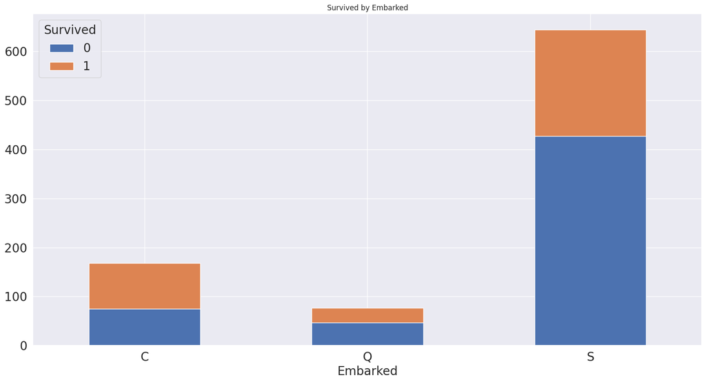

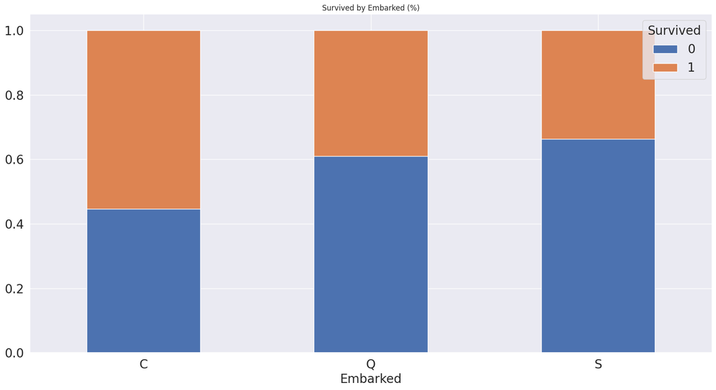

```python
def survived_stack_bar(col_name, df):
    pd.crosstab(df[col_name], df['Survived']).plot(kind='bar', stacked=True, title='Survived by {}'.format(col_name))
    plt.xticks(rotation=0)
    pd.crosstab(df[col_name], df['Survived'], normalize='index').\
    plot(kind='bar', stacked=True,title='Survived by {} (%)'.format(col_name))
    plt.xticks(rotation=0)
survived_stack_bar('Embarked',train_df)
```

```python
def create_pie_chart_of_count(df, column_name):
    df_not_null = df[~df[column_name].isnull()]
    fig = px.pie(df_not_null.groupby([column_name]).size().reset_index(name='count'), names=column_name, values='count')
    fig.show()

create_pie_chart_of_count(train_df, 'Embarked')
```

[interactive chart not shown]

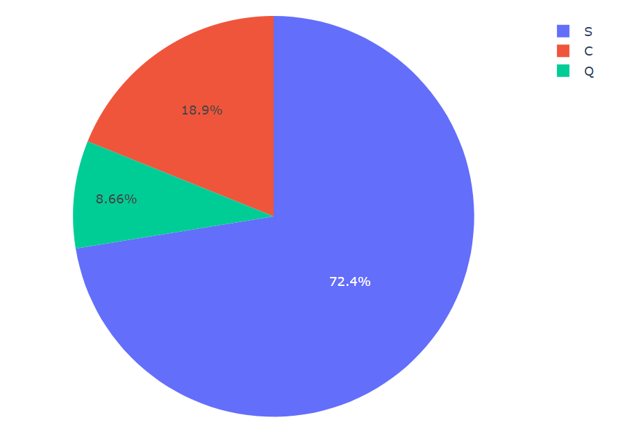

```python
train_df['Age'].fillna(train_df['Age'].mean(), inplace=True) #filling mean

most_frequent_value = train_df['Embarked'].mode()[0] # filling Embarked
train_df['Embarked'] = train_df['Embarked'].fillna(most_frequent_value)
train_df = train_df.drop('Cabin', axis=1)
```

Doing the same in the test dataset:

```python
# Calculate the total number of missing values in each column and sort in descending order
missing_total = test_df.isnull().sum().sort_values(ascending=False)

# Calculate the percentage of missing values for each column and sort in descending order
missing_percentage = (test_df.isnull().sum() / len(test_df)).sort_values(ascending=False)

# Combine the total and percentage of missing values into a single DataFrame
missing_info = pd.concat([missing_total, missing_percentage], axis=1, keys=['Total Missing', 'Percentage'])

# Display the columns with the most missing data
print("Missing data in the test dataset:")
missing_info.head(len(columns))
```

```
Missing data in the test dataset:
```

|  | Total Missing | Percentage |
| --- | --- | --- |
| Cabin | 327 | 0.782297 |
| Age | 86 | 0.205742 |
| Fare | 1 | 0.002392 |
| PassengerId | 0 | 0.000000 |
| Pclass | 0 | 0.000000 |
| Name | 0 | 0.000000 |
| Sex | 0 | 0.000000 |
| SibSp | 0 | 0.000000 |
| Parch | 0 | 0.000000 |
| Ticket | 0 | 0.000000 |
| Embarked | 0 | 0.000000 |

```python
# Fill missing 'Age' with the mean of 'Age' in test_df
test_df['Age'].fillna(test_df['Age'].mean(), inplace=True)  # Filling with mean

# Fill missing 'Embarked' with the most frequent value in 'Embarked' in test_df
most_frequent_value = test_df['Embarked'].mode()[0]  # Most frequent value
test_df['Embarked'] = test_df['Embarked'].fillna(most_frequent_value)

# Drop the 'Cabin' column in test_df
test_df = test_df.drop('Cabin', axis=1)

# Fill missing 'Embarked' with the most frequent value in 'Fare' in test_df
most_frequent_value = test_df['Fare'].mode()[0]  # Most frequent value
test_df['Fare'] = test_df['Fare'].fillna(most_frequent_value)
```

Check if we managed to fill the missing values

```python
train_df.isnull().sum().sort_values(ascending=False)
```

```
PassengerId    0
Survived       0
Pclass         0
Name           0
Sex            0
Age            0
SibSp          0
Parch          0
Ticket         0
Fare           0
Embarked       0
dtype: int64
```

```python
test_df.isnull().sum().sort_values(ascending=False)
```

```
PassengerId    0
Pclass         0
Name           0
Sex            0
Age            0
SibSp          0
Parch          0
Ticket         0
Fare           0
Embarked       0
dtype: int64
```

Drop Cabin collumn since too many attributes are missing, also, based on the description of the table both 'cabin' & 'fare' columns describing the position on the deck (people who paid more had better position on the titanic)

Drop 'PassengerID','Name' since they do not impact anything

Drop 'Ticket'- (people who paid more had better position on the titanic- the ticket impacted by it)

```python
# Extract the 'Id' column from df_test
id_test = test_df['PassengerId']

# Dropping specified columns from train_df
train_df = train_df.drop(['PassengerId', 'Name', 'Ticket'], axis=1)

# Dropping specified columns from test_df
test_df = test_df.drop(['PassengerId', 'Name', 'Ticket'], axis=1)
```

```python
train_df.columns
```

```
Index(['Survived', 'Pclass', 'Sex', 'Age', 'SibSp', 'Parch', 'Fare',
       'Embarked'],
      dtype='object')
```

```python
test_df.columns
```

```
Index(['Pclass', 'Sex', 'Age', 'SibSp', 'Parch', 'Fare', 'Embarked'], dtype='object')
```

# Calculating Survival Rates by Gender on the Titanic Dataset:

```python
women = train_df.loc[train_df.Sex == 'female']["Survived"]
rate_women = sum(women)/len(women)

print("% of women who survived:", rate_women)

men = train_df.loc[train_df.Sex == 'male']["Survived"]
rate_men = sum(men)/len(men)

print("% of men who survived:", rate_men)
```

```
% of women who survived: 0.7420382165605095
% of men who survived: 0.18890814558058924
```

The results show a significant difference in survival rates between genders on the Titanic:

- **74.2% of women survived**, indicating a much higher survival likelihood for women.
- **18.9% of men survived**, showing a significantly lower survival rate for men.

This reflects the "women and children first" policy often associated with maritime disasters.

## Visualize

```python
def visualize_feature_relationship(data, column, target='Survived'):
    plt.figure(figsize=(8, 5))
    # Determine data type of the column
    if data[column].dtype == 'object' or data[column].nunique() < 10:  # Categorical columns
        sns.countplot(data=data, x=column, hue=target, palette='viridis')
        plt.title(f'{column} vs {target}')
        plt.xlabel(column)
        plt.ylabel('Count')
        plt.legend(title=target)
    else:  # Numerical columns
        sns.kdeplot(data=data, x=column, hue=target, fill=True, palette='viridis', alpha=0.5)
        plt.title(f'{column} Distribution by {target}')
        plt.xlabel(column)
        plt.ylabel('Density')
    plt.show()
```

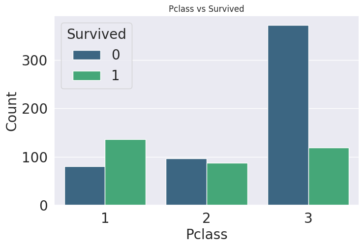

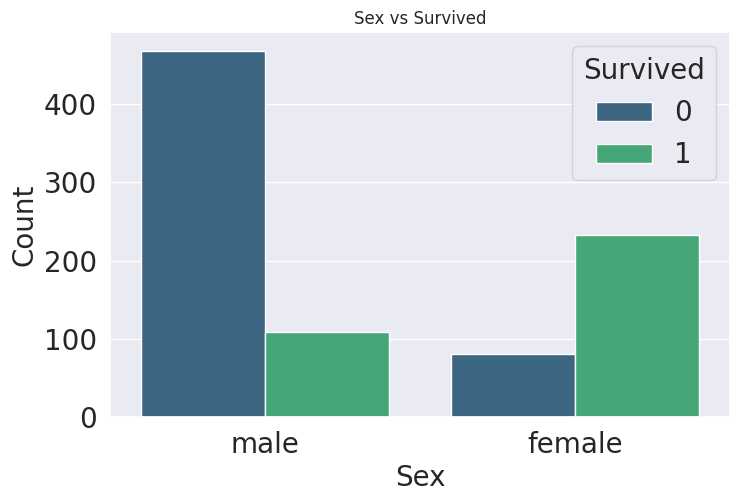

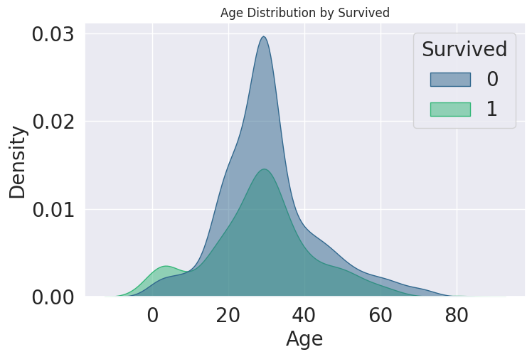

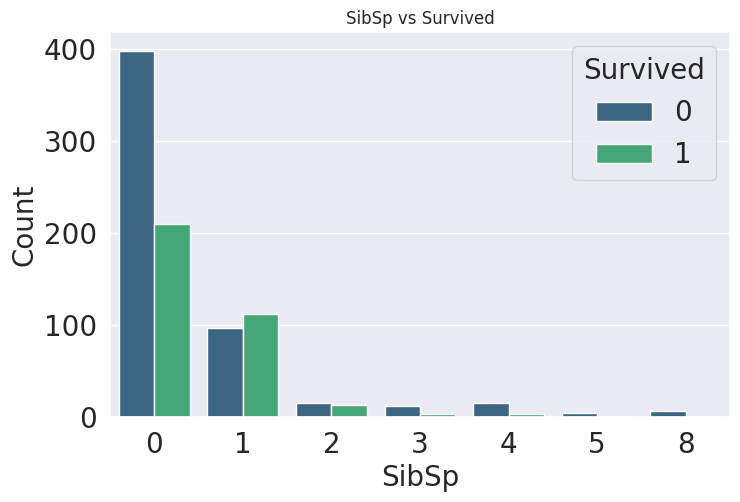

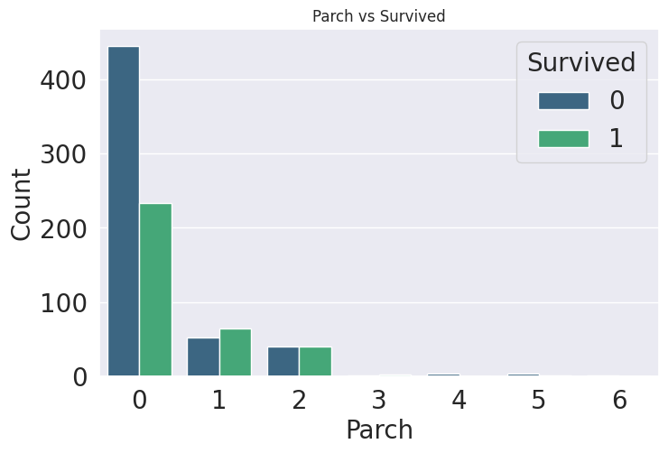

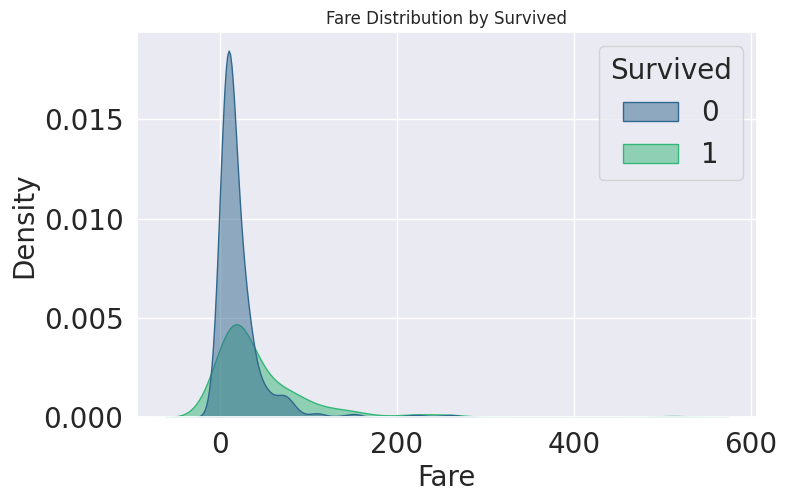

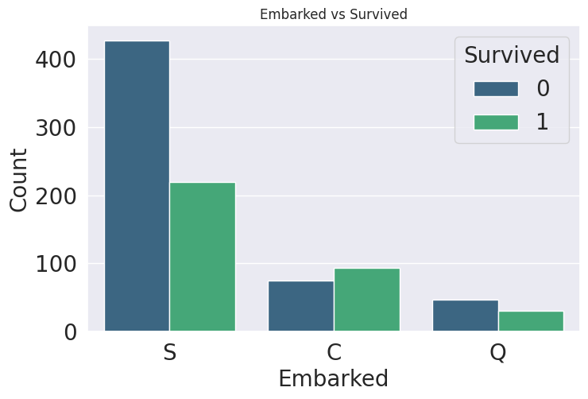

```python
columns_to_graph=train_df.columns.drop(['Survived'])
for col in columns_to_graph:
    visualize_feature_relationship(train_df, col)
```

## HeatMap

```python
def plot_correlation_heatmap(data, numeric_columns, title="Correlation Heatmap"):
    # Select numeric features only

    # Compute the correlation matrix
    correlation_matrix = numeric_columns.corr()

    # Plot the heatmap
    plt.figure(figsize=(10, 8))
    sns.heatmap(correlation_matrix, annot=True, fmt=".2f", cmap="coolwarm", cbar=True, square=True)
    plt.title(title)
    plt.show()
```

Pay attention: Correlation only captures linear relationships. Non-linear dependencies between features and the target won't be reflected. For example, a quadratic or other non-linear relationship may show little to no correlation but still be predictive.

therefore, we should take the result of the correlation matrix with a grain of salt.

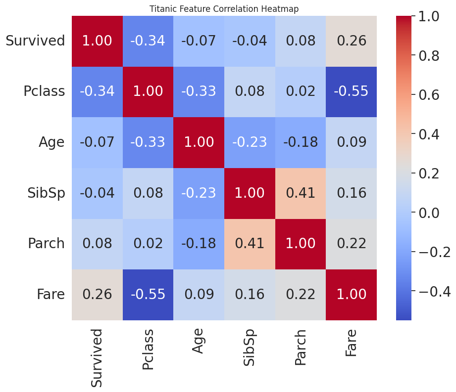

```python
numeric_columns = train_df.select_dtypes(include=['number'])

plot_correlation_heatmap(train_df, numeric_columns, title="Titanic Feature Correlation Heatmap")
```

## Encoding

**Divide the data to features and target:**

```python
print(columns_to_graph)
t = train_df['Survived'].copy()
print(t)

#t.unique()

X = train_df[columns_to_graph]
print(X)

#print(train_df)
```

```
Index(['Pclass', 'Sex', 'Age', 'SibSp', 'Parch', 'Fare', 'Embarked'], dtype='object')
0      0
1      1
2      1
3      1
4      0
      ..
886    0
887    1
888    0
889    1
890    0
Name: Survived, Length: 891, dtype: int64
     Pclass     Sex        Age  SibSp  Parch     Fare Embarked
0         3    male  22.000000      1      0   7.2500        S
1         1  female  38.000000      1      0  71.2833        C
2         3  female  26.000000      0      0   7.9250        S
3         1  female  35.000000      1      0  53.1000        S
4         3    male  35.000000      0      0   8.0500        S
..      ...     ...        ...    ...    ...      ...      ...
886       2    male  27.000000      0      0  13.0000        S
887       1  female  19.000000      0      0  30.0000        S
888       3  female  29.699118      1      2  23.4500        S
889       1    male  26.000000      0      0  30.0000        C
890       3    male  32.000000      0      0   7.7500        Q

[891 rows x 7 columns]
```

```python
# Define numerical and categorical columns
numerical_cols = X.select_dtypes(include=['int64', 'float64']).columns  # numeric features
categorical_cols = X.select_dtypes(include=['object', 'bool']).columns  # categorical features

# Define the ColumnTransformer with OneHotEncoder for both 'Sex' and 'Embarked'
ct_enc_std = ColumnTransformer([
    ('onehot_embarked', OneHotEncoder(), ['Embarked']),  # One-hot encode 'Embarked'
    ('onehot_sex', OneHotEncoder(), ['Sex']),  # One-hot encode 'Sex'
    ('standard', StandardScaler(), numerical_cols)  # Standardize numerical features
])

# Fit the ColumnTransformer on the data
ct_enc_std.fit(X)
# Create a DataFrame with the correct column names after transformation
onehot_embarked_feature_names = ct_enc_std.named_transformers_['onehot_embarked'].get_feature_names_out(['Embarked'])
onehot_sex_feature_names = ct_enc_std.named_transformers_['onehot_sex'].get_feature_names_out(['Sex'])
numeric_feature_names = numerical_cols.tolist()

# Combine all feature names into one list
all_feature_names = list(onehot_embarked_feature_names) + list(onehot_sex_feature_names) + numeric_feature_names

# Transform the data and create a new DataFrame
X_transformed = ct_enc_std.transform(X)
X_encoded = pd.DataFrame(X_transformed, columns=all_feature_names)


X_encoded.columns
```

```
Index(['Embarked_C', 'Embarked_Q', 'Embarked_S', 'Sex_female', 'Sex_male',
       'Pclass', 'Age', 'SibSp', 'Parch', 'Fare'],
      dtype='object')
```

**Creating a Copy of Encoded Dataset for K-Nearest Neighbors (KNN)**

```python
X_encoded_KNN = X_encoded.copy()
```

### Explanation (Shortened):

- **Numerical Features**: `Pclass`, `Age`, `SibSp`, `Parch`, `Fare` (Standardized).
- **Categorical Features**:
  - `Embarked`: One-hot encoded into `Embarked_C`, `Embarked_Q`, `Embarked_S`.
  - `Sex`: One-hot encoded into `Sex_female`, `Sex_male`.
- **Result**: Data transformed into a DataFrame with these feature columns.

**The test dataframe**

```python
# Define numerical and categorical columns
numerical_cols = test_df.select_dtypes(include=['int64', 'float64']).columns  # numeric features
categorical_cols = test_df.select_dtypes(include=['object', 'bool']).columns  # categorical features

# Define the ColumnTransformer with OneHotEncoder for both 'Sex' and 'Embarked'
ct_enc_std = ColumnTransformer([
    ('onehot_embarked', OneHotEncoder(), ['Embarked']),  # One-hot encode 'Embarked'
    ('onehot_sex', OneHotEncoder(), ['Sex']),  # One-hot encode 'Sex'
    ('standard', StandardScaler(), numerical_cols)  # Standardize numerical features
])

# Fit the ColumnTransformer on the data
ct_enc_std.fit(test_df)
# Create a DataFrame with the correct column names after transformation
onehot_embarked_feature_names = ct_enc_std.named_transformers_['onehot_embarked'].get_feature_names_out(['Embarked'])
onehot_sex_feature_names = ct_enc_std.named_transformers_['onehot_sex'].get_feature_names_out(['Sex'])
numeric_feature_names = numerical_cols.tolist()

# Combine all feature names into one list
all_feature_names = list(onehot_embarked_feature_names) + list(onehot_sex_feature_names) + numeric_feature_names

# Transform the data and create a new DataFrame
test_df_transformed = ct_enc_std.transform(test_df)
test_df_encoded = pd.DataFrame(test_df_transformed, columns=all_feature_names)
test_df_encoded_KNN = pd.DataFrame(test_df_transformed, columns=all_feature_names)

test_df_encoded.columns
```

```
Index(['Embarked_C', 'Embarked_Q', 'Embarked_S', 'Sex_female', 'Sex_male',
       'Pclass', 'Age', 'SibSp', 'Parch', 'Fare'],
      dtype='object')
```

## Checks if the dataset meets the requirements for LDA:

Limitations: Assumes that data for each class is normally distributed. Assumes that all classes have the same variance (homoscedasticity). Struggles with non-linear class boundaries

```python
from scipy.stats import shapiro
import numpy as np
import pandas as pd

def check_lda_requirements(X, y):
    """
    Checks if the dataset meets the requirements for LDA.
    """
    issues = []

    # Check 1: Labels are discrete
    if not pd.Series(y).dtype.name.startswith("int"):
        issues.append("Target labels must be discrete (categorical).")
    else:
        print("Labels are discrete (categorical).")

    # Check 2: At least two classes
    if len(np.unique(y)) < 2:
        issues.append("Dataset must have at least two distinct classes in the target labels.")
    else:
        print("At least two distinct classes found.")

    # Check 3: Sufficient samples
    n_samples, n_features = X.shape
    if n_samples <= n_features + 1:
        issues.append(f"Insufficient samples. Need more than {n_features + 1} samples for {n_features} features.")
    else:
        print(f"Sufficient samples. {n_samples} samples found.")

    # Check 4: Normal distribution of features
    X = X.to_numpy() if isinstance(X, pd.DataFrame) else X
    for i in range(X.shape[1]):
        stat, p_value = shapiro(X[:, i])
        if p_value <= 0.05:
            issues.append(f"Feature {i+1} does not follow a normal distribution.")
        else:
            print(f"Feature {i+1} follows a normal distribution (p-value = {p_value:.4f}).")

    # Check 5: Shared covariance assumption (Box's M Test)
    try:
        cov_matrix = []
        for class_value in np.unique(y):
            X_class = X[y == class_value]
            cov_matrix.append(np.cov(X_class, rowvar=False))

        # Check if covariance matrices for different classes are similar
        if len(set([cov_matrix[i].shape for i in range(len(cov_matrix))])) > 1:
            issues.append("Covariance matrices for the classes are not similar. Box's M Test failed.")
        else:
            print("Covariance matrices are similar across classes.")
    except Exception as e:
        issues.append(f"Error in covariance check: {str(e)}")

    # Check 6: Low multicollinearity
    correlation_matrix = np.corrcoef(X.T)
    if np.any(np.abs(correlation_matrix[np.triu_indices_from(correlation_matrix, 1)]) > 0.9):
        issues.append("Highly correlated features detected (correlation > 0.9).")
    else:
        print("No highly correlated features detected.")

    # Check 7: Features with low variance
    if np.any(np.var(X, axis=0) < 1e-5):
        issues.append("Some features have very low variance (near constant).")
    else:
        print("No features with very low variance detected.")

    # Check 8: Balanced dataset
    class_counts = pd.Series(y).value_counts()
    imbalance_ratio = class_counts.max() / class_counts.min()
    if imbalance_ratio > 5:
        issues.append("Class imbalance detected. Imbalance ratio exceeds 5:1.")
    else:
        print(f"Class balance is acceptable. Imbalance ratio: {imbalance_ratio:.2f}.")

    # Final decision
    if issues:
        print("\nThe dataset is NOT suitable for LDA. Issues found:")
        for issue in issues:
            print(f"- {issue}")
        return False
    else:
        print("\nThe dataset is suitable for LDA.")
        return True

check_lda_requirements(X_encoded, t)
```

```
Labels are discrete (categorical).
At least two distinct classes found.
Sufficient samples. 891 samples found.
Covariance matrices are similar across classes.
No features with very low variance detected.
Class balance is acceptable. Imbalance ratio: 1.61.

The dataset is NOT suitable for LDA. Issues found:
- Feature 1 does not follow a normal distribution.
- Feature 2 does not follow a normal distribution.
- Feature 3 does not follow a normal distribution.
- Feature 4 does not follow a normal distribution.
- Feature 5 does not follow a normal distribution.
- Feature 6 does not follow a normal distribution.
- Feature 7 does not follow a normal distribution.
- Feature 8 does not follow a normal distribution.
- Feature 9 does not follow a normal distribution.
- Feature 10 does not follow a normal distribution.
- Highly correlated features detected (correlation > 0.9).
```

```
False
```

### The usage of LDA

The output of the `check_lda_requirements` function indicates that while certain prerequisites for Linear Discriminant Analysis (LDA) are met, the dataset is not suitable for LDA due to significant violations of key assumptions. Specifically, the dataset satisfies the requirements of having discrete target labels, sufficient samples (891 samples for 10 features), similar covariance matrices across classes, no features with very low variance, and acceptable class balance (imbalance ratio of 1.61). However, critical issues were identified: none of the features follow a normal distribution (as evidenced by the Shapiro-Wilk test results with p-values below 0.05 for all features), and the dataset contains highly correlated features (correlation > 0.9). These violations undermine the assumptions of normality and independence required for LDA, indicating that the model may not perform reliably on this dataset. To address these issues, consider feature transformation (e.g., log or Box-Cox transformations) to improve normality, and use techniques like PCA to reduce multicollinearity. **summry:** The dataset is not currently suitable for **Linear Discriminant Analysis (LDA)** due to the following issues:

1. **Non-Normality of Features:** All features fail the normality test, violating LDA's assumption that features within each class are normally distributed.
2. **High Multicollinearity:** Some features are highly correlated (correlation > 0.9), which violates the assumption of weakly correlated or independent features.

## **Feature selection**

We want to choose the best features for our use case. We have learned 3 methods of Feature Selection:

1. Forward Feature Selection
2. Backward Feature Selection
3. Hybrid Feature Selection

In Forward Feature Selection we start from one feature and add features (all combinations) until we reach the number of maximum features or until we reach the best score.

In Backward Feature Selection we start from the full feature set and remove features until we reach the number of minimum features or until we reach the best score (early stopping).

In Hybrid Feature Selection, we start from zero features and add/remove features until we reach the best score.

We will use Scikit-learn Recursive Feature Elimination (RFE) that is based on the Backward Feature Selection. Note: We will specify the target number of features to find and the selector will stop when it will reach this number of features.

Let's find the best n_features_to_select=3 features on our dataset.

We can use CV (Cross-Validation) instead of breaking the data to train-validation splits.

## 1.RFE

```python
# choose the best 3 features of this dataset with SGDClassifier.

from sklearn.linear_model import LogisticRegression
selector_RFE = RFE(LogisticRegression(random_state=1), n_features_to_select=3).fit(X_encoded, t) # need to specify the model and the number of features and train the model
selector_RFE.support_ # mask the features that give the best model
```

```
array([False, False, False,  True,  True,  True, False, False, False,
       False])
```

```python
X_encoded.loc[:, selector_RFE.support_]
```

|  | Sex_female | Sex_male | Pclass |
| --- | --- | --- | --- |
| 0 | 0.0 | 1.0 | 0.827377 |
| 1 | 1.0 | 0.0 | -1.566107 |
| 2 | 1.0 | 0.0 | 0.827377 |
| 3 | 1.0 | 0.0 | -1.566107 |
| 4 | 0.0 | 1.0 | 0.827377 |
| ... | ... | ... | ... |
| 886 | 0.0 | 1.0 | -0.369365 |
| 887 | 1.0 | 0.0 | -1.566107 |
| 888 | 1.0 | 0.0 | 0.827377 |
| 889 | 0.0 | 1.0 | -1.566107 |
| 890 | 0.0 | 1.0 | 0.827377 |

891 rows × 3 columns

Based on the output:

## 2.RFECV

RFECV using Logistic Regression:

```python
selector = RFECV(
    LogisticRegression(random_state=1),
    cv=RepeatedKFold(n_splits=5, n_repeats=10, random_state=1)
).fit(X_encoded, t)

# Display selected features
selected_features = X_encoded.columns[selector.support_]
print("Selected features:")
print(selected_features)


X_selected_backword = X_encoded[selected_features]

# Plot feature selection results
fig = go.Figure()
fig.add_trace(go.Scatter(
    x=[i for i in range(1, len(selector.feature_names_in_) + 1)],
    y=selector.cv_results_['mean_test_score'],
    mode='lines+markers',
    name='Cross-Validation Score'
))
```

```
Selected features:
Index(['Embarked_C', 'Embarked_Q', 'Embarked_S', 'Sex_female', 'Sex_male',
       'Pclass', 'Age', 'SibSp', 'Fare'],
      dtype='object')
```

[interactive chart not shown]

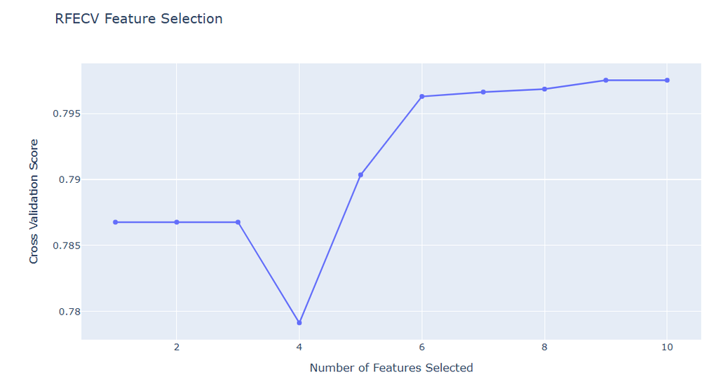

**Observations:** There is a drop in performance at 4 features, indicating that this subset may not adequately represent the data. After 6 features, the cross-validation score stabilizes and shows the best performance, implying that 6 or more features might be optimal for this model.

```python
print(selector.feature_names_in_)
print(selector.ranking_)
print(selector.support_)
print(selector.get_feature_names_out())
```

```
['Embarked_C' 'Embarked_Q' 'Embarked_S' 'Sex_female' 'Sex_male' 'Pclass'
 'Age' 'SibSp' 'Parch' 'Fare']
[1 1 1 1 1 1 1 1 2 1]
[ True  True  True  True  True  True  True  True False  True]
['Embarked_C' 'Embarked_Q' 'Embarked_S' 'Sex_female' 'Sex_male' 'Pclass'
 'Age' 'SibSp' 'Fare']
```

## Forward feature selection:

```python
from sklearn.feature_selection import SequentialFeatureSelector
from sklearn.linear_model import LogisticRegression
from sklearn.model_selection import RepeatedKFold
import plotly.graph_objects as go

# Forward Selection
forward_selector = SequentialFeatureSelector(
    LogisticRegression(random_state=1),
    n_features_to_select="auto",  # Automatically find the optimal number of features
    direction='forward',  # Forward selection
    scoring='accuracy',   # Use accuracy for scoring
    cv=RepeatedKFold(n_splits=5, n_repeats=10, random_state=1),
    n_jobs=-1
).fit(X_encoded, t)

# Display selected features
selected_features_forward = X_encoded.columns[forward_selector.get_support()]
print("Selected features (Forward Selection):")
print(selected_features_forward)

X_selected_forward = X_encoded[selected_features_forward]

# No direct scoring plot is available in this case
```

```
Selected features (Forward Selection):
Index(['Embarked_Q', 'Sex_female', 'Sex_male', 'Pclass', 'SibSp'], dtype='object')
```

The optimal features selected by Forward Feature Selection are:

'Embarked_Q': Indicates passengers who embarked at "Q" port (encoded as binary). 'Sex_female' and 'Sex_male': Encoded binary features for passenger gender. 'Pclass' 'SibSp': Number of siblings/spouses aboard with the passenger.

These features are considered the most relevant for predicting the target variable (t), based on their contribution to improving model accuracy during cross-validation.

## Hybrid feature selection:

```python
from mlxtend.feature_selection import SequentialFeatureSelector as SFS
from sklearn.linear_model import LogisticRegression
from sklearn.model_selection import RepeatedKFold
import plotly.graph_objects as go

# Hybrid Selection (Forward and Backward)
hybrid_selector = SFS(
    LogisticRegression(random_state=1),
    k_features="best",  # Automatically determine optimal features
    forward=True,  # Start with forward selection
    floating=True,  # Allow backward elimination during selection
    scoring='accuracy',
    cv=RepeatedKFold(n_splits=5, n_repeats=10, random_state=1),
    n_jobs=-1
).fit(X_encoded.values, t)

# Display selected features
selected_features_hybrid = X_encoded.columns[list(hybrid_selector.k_feature_idx_)]
print("Selected features (Hybrid Selection):")
print(selected_features_hybrid)

X_selected_hybrid = X_encoded[selected_features_hybrid]
```

```
Selected features (Hybrid Selection):
Index(['Embarked_Q', 'Sex_female', 'Pclass', 'SibSp'], dtype='object')
```

The optimal features selected by Hybrid Feature Selection are:

'Embarked_Q': Passengers who embarked at "Q" port (encoded as binary). Embarkation location can influence survival due to socioeconomic factors. 'Sex_female': Indicates female passengers, a critical feature due to gender-based survival priority ("women and children first"). 'Pclass': Passenger class, which is strongly associated with survival rates (e.g., 1st class passengers had better access to lifeboats). 'SibSp': Number of siblings/spouses aboard, which could impact survival (e.g., family influence during evacuation).

## Optimal K Selection for K-Nearest Neighbors (KNN) Using Feature Subsets

```python
from sklearn.model_selection import GridSearchCV
from sklearn.neighbors import KNeighborsClassifier
from sklearn.pipeline import make_pipeline
from sklearn.model_selection import train_test_split
from sklearn.metrics import accuracy_score

dataframes = [X_selected_backword, X_selected_forward , X_selected_hybrid]
optimal_k = []

for df in dataframes:
    X_train, X_val, t_train, t_val = train_test_split(df, t, test_size=0.25, random_state=1)

    # run KNN on the dataset and find best K by accuracy
    #hyper_parameters = {'n_neighbors': list(range(1, 20))}

    hyper_parameters = {
        'kneighborsclassifier__n_neighbors': list(range(1, 20))  # Search for neighbors from 5 to 20
    }

    model_pipe = make_pipeline(
        ColumnTransformer([
            ("encoding", OrdinalEncoder(handle_unknown='use_encoded_value', unknown_value=-1), X_train.select_dtypes(include=['object', 'bool']).columns),
            ("scaling", StandardScaler(), X_train.select_dtypes(include=['int64', 'float64']).columns)
        ]),
        KNeighborsClassifier()
    )
    # KNeighborsClassifier(n_neighbors=5)
    gs_neigh_model = GridSearchCV(model_pipe, hyper_parameters).fit(df, t)
    print('Accuracy score for classification:')
    print('gs_neigh_model', gs_neigh_model.best_score_)
    print('best params', gs_neigh_model.best_params_)
    optimal_k.append(gs_neigh_model.best_params_["kneighborsclassifier__n_neighbors"])
```

```
Accuracy score for classification:
gs_neigh_model 0.8215240725629276
best params {'kneighborsclassifier__n_neighbors': 14}
Accuracy score for classification:
gs_neigh_model 0.8002510827945514
best params {'kneighborsclassifier__n_neighbors': 7}
Accuracy score for classification:
gs_neigh_model 0.8002510827945514
best params {'kneighborsclassifier__n_neighbors': 7}
```

#### **Summary:**

The **K-Nearest Neighbors (KNN)** algorithm was applied to three feature subsets—Backward Selection (`X_selected_backword`), Forward Selection (`X_selected_forward`), and Hybrid Selection (`X_selected_hybrid`)—to determine the optimal number of neighbors (**K**) using **GridSearchCV** with cross-validation. Accuracy scores and optimal K values were identified for each subset:

1. **Backward Selection:**
   - Accuracy: **82.15%**
   - Optimal K: **14**
2. **Forward Selection:**
   - Accuracy: **80.03%**
   - Optimal K: **7**
3. **Hybrid Selection:**
   - Accuracy: **80.03%**
   - Optimal K: **7**

#### **Conclusion:**

The **Backward Selection** feature subset yielded the highest accuracy (**82.15%**) with an optimal K value of **14**, making it the most suitable feature subset for KNN in this context.

## KPI AND Confusion Matrix

TP (True Positive) - The model classified correctly that a sample is positive. TN (True Negative) - The model classified correctly that a sample is negative. FP (False Positive) - The model classified a sample as positive but the sample is actually negative. FN (False Negative) - The model classified a sample as negative but the sample is actually positive.

These KPIs help evaluate model performance, especially in classification tasks.

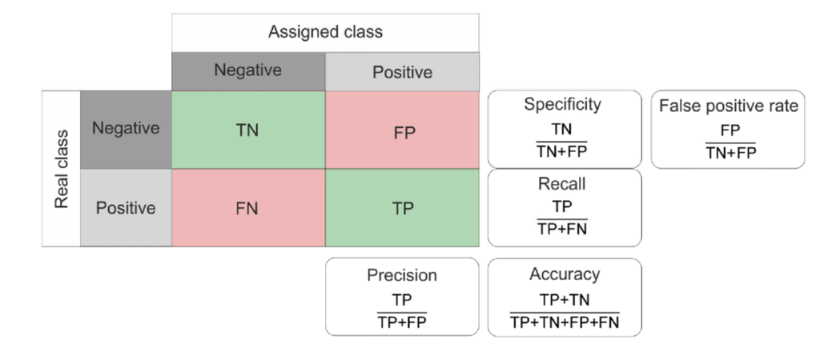

## Bootstrap Evaluation of Models Using Feature Selection Methods

**Overview:** This experiment evaluates the performance of Multinomial Naive Bayes (MultinomialNB) and K-Nearest Neighbors (KNN) classifiers using three feature selection methods: Backward Elimination, Forward Selection, and Hybrid Selection. Bootstrap sampling and bagging are applied to analyze the models' accuracy, log loss, and consistency over multiple iterations.

```
========================================
Feature Selection Method: Backward Elimination
========================================

--------------------
Model: MultinomialNB
--------------------
Running bootstrap iterations for MultinomialNB with Backward Elimination

Results for MultinomialNB using Backward Elimination:
Average Training Accuracy: 0.7892
Average Validation Accuracy: 0.7885
Average Training Loss (Log Loss): 0.4825
Average Validation Loss (Log Loss): 0.4860

Training KPIs for MultinomialNB using Backward Elimination:
Precision: 0.7803
Recall: 0.7061
F1 Score: 0.7413
Specificity: 0.8732
False Positive Rate: 0.1268

Validation KPIs for MultinomialNB using Backward Elimination:
Precision: 0.7437
Recall: 0.6871
F1 Score: 0.7143
Specificity: 0.8525
False Positive Rate: 0.1475
```

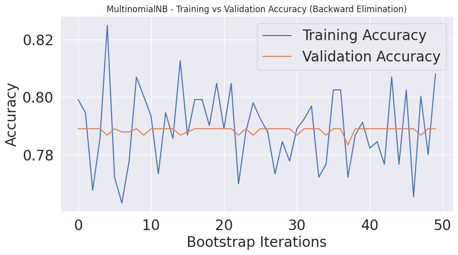

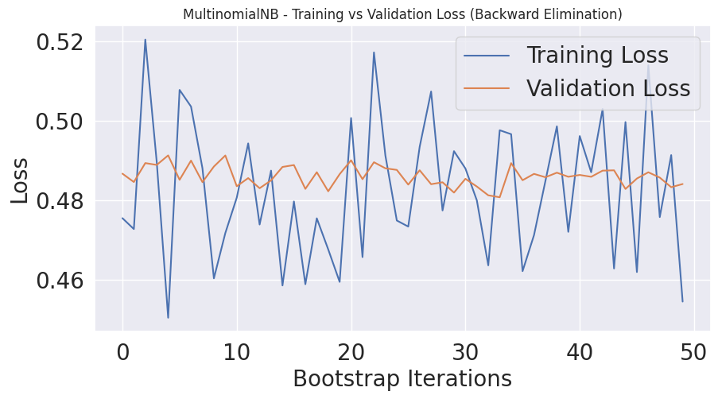

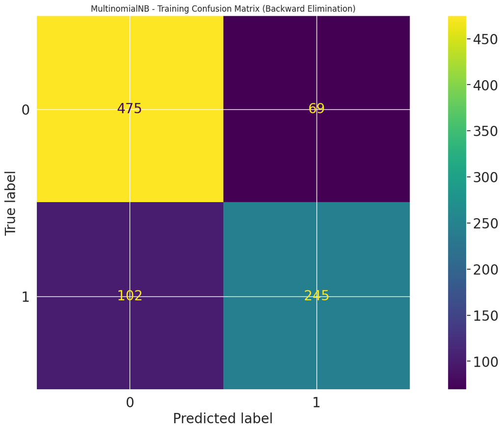

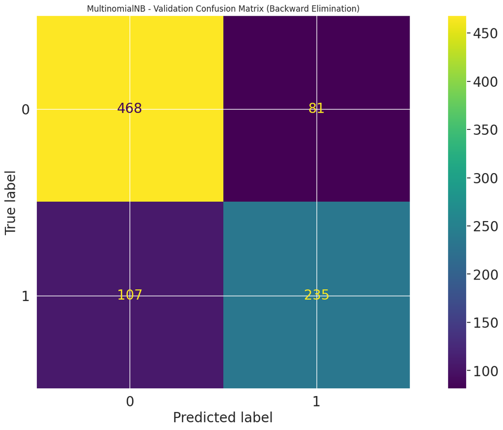

```
--------------------
Model: KNeighborsClassifier
--------------------
Running bootstrap iterations for KNeighborsClassifier with Backward Elimination

Results for KNeighborsClassifier using Backward Elimination:
Average Training Accuracy: 0.8446
Average Validation Accuracy: 0.8217
Average Training Loss (Log Loss): 0.3366
Average Validation Loss (Log Loss): 0.6083

Training KPIs for KNeighborsClassifier using Backward Elimination:
Precision: 0.8627
Recall: 0.6769
F1 Score: 0.7586
Specificity: 0.9382
False Positive Rate: 0.0618

Validation KPIs for KNeighborsClassifier using Backward Elimination:
Precision: 0.8277
Recall: 0.6462
F1 Score: 0.7258
Specificity: 0.9162
False Positive Rate: 0.0838
```

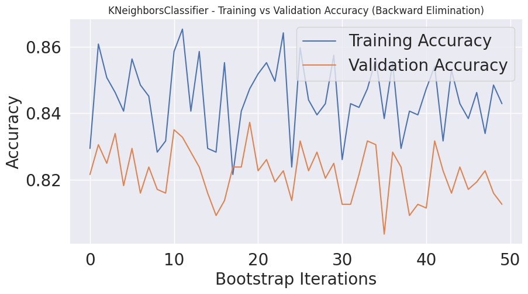

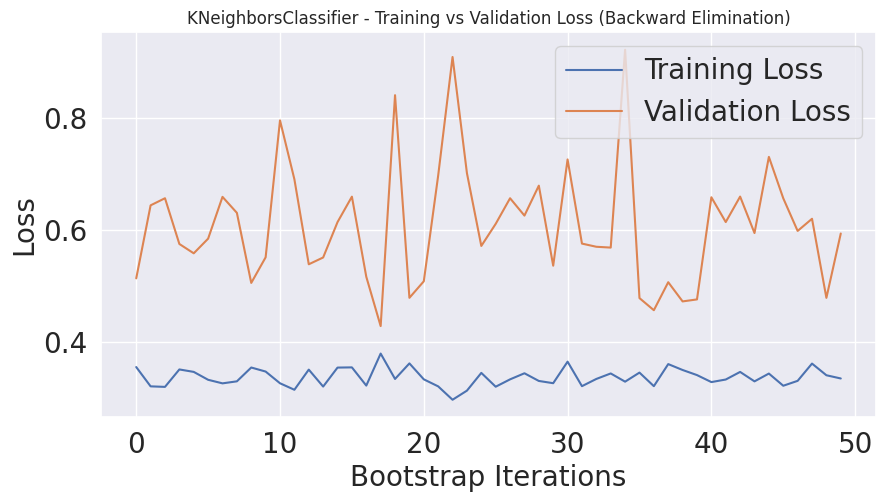

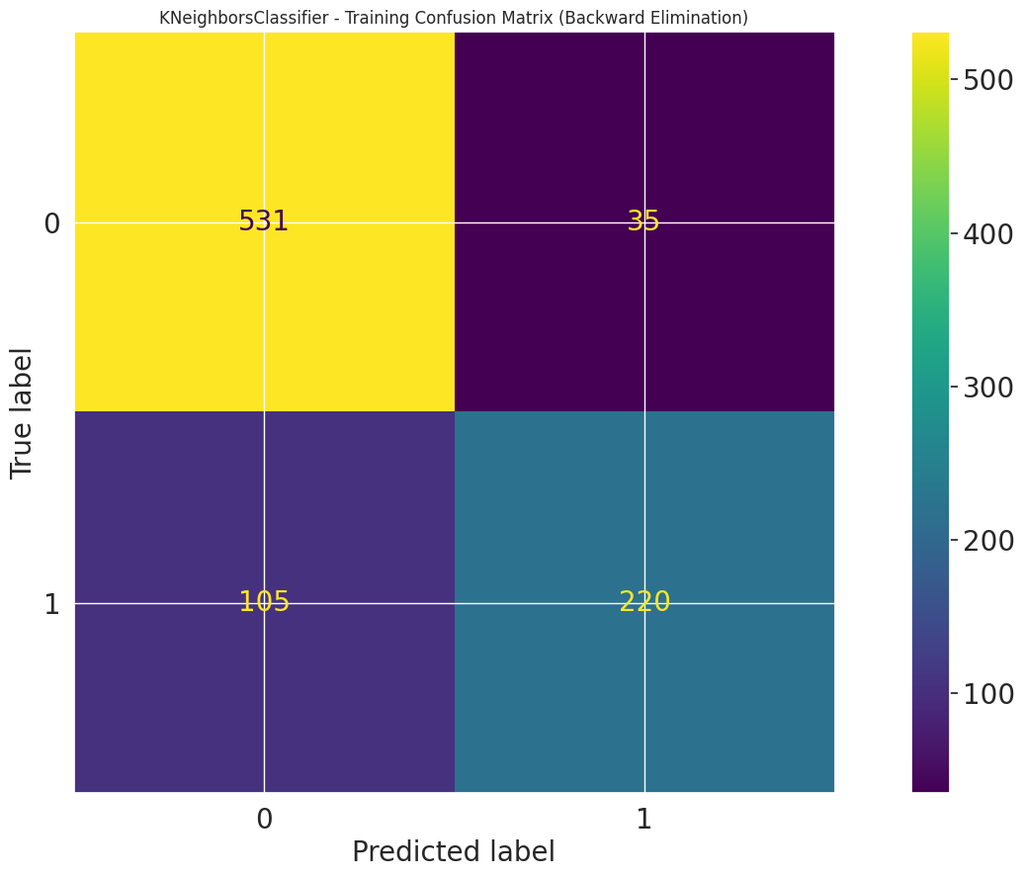

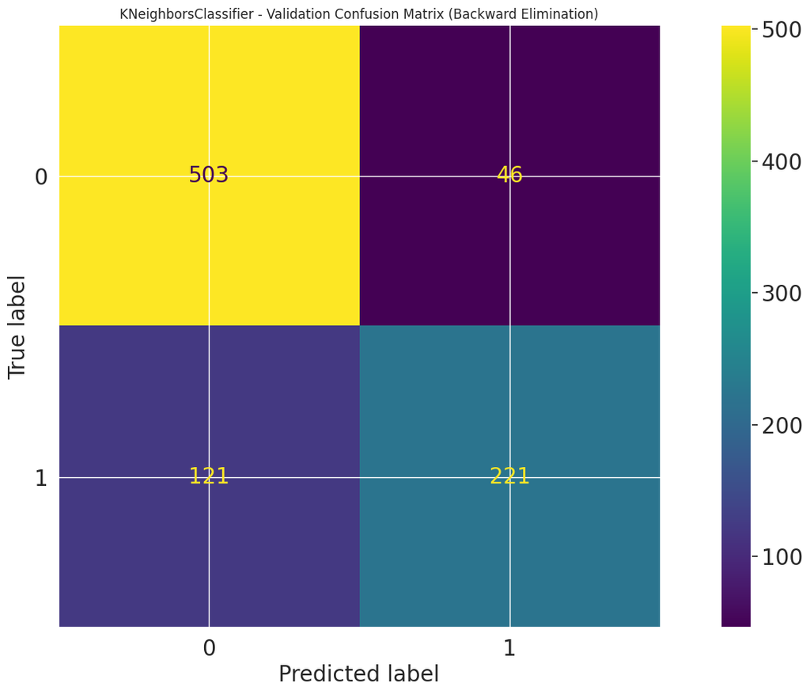

```
========================================
Feature Selection Method: Forward Selection
========================================

--------------------
Model: MultinomialNB
--------------------
Running bootstrap iterations for MultinomialNB with Forward Selection

Results for MultinomialNB using Forward Selection:
Average Training Accuracy: 0.7863
Average Validation Accuracy: 0.7868
Average Training Loss (Log Loss): 0.4992
Average Validation Loss (Log Loss): 0.5027

Training KPIs for MultinomialNB using Forward Selection:
Precision: 0.6634
Recall: 0.6223
F1 Score: 0.6422
Specificity: 0.8204
False Positive Rate: 0.1796

Validation KPIs for MultinomialNB using Forward Selection:
Precision: 0.7420
Recall: 0.6813
F1 Score: 0.7104
Specificity: 0.8525
False Positive Rate: 0.1475
```

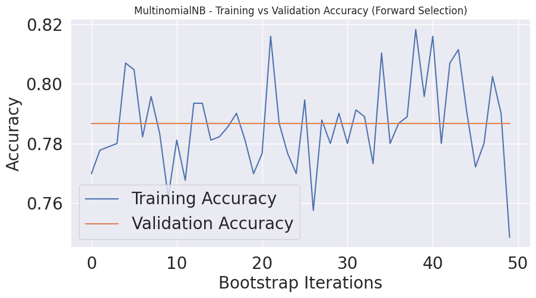

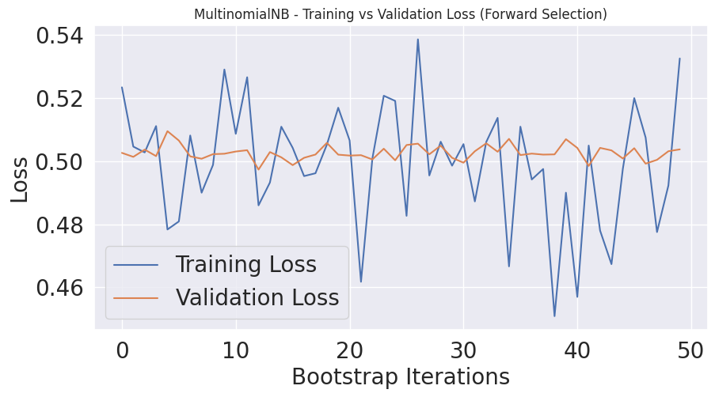

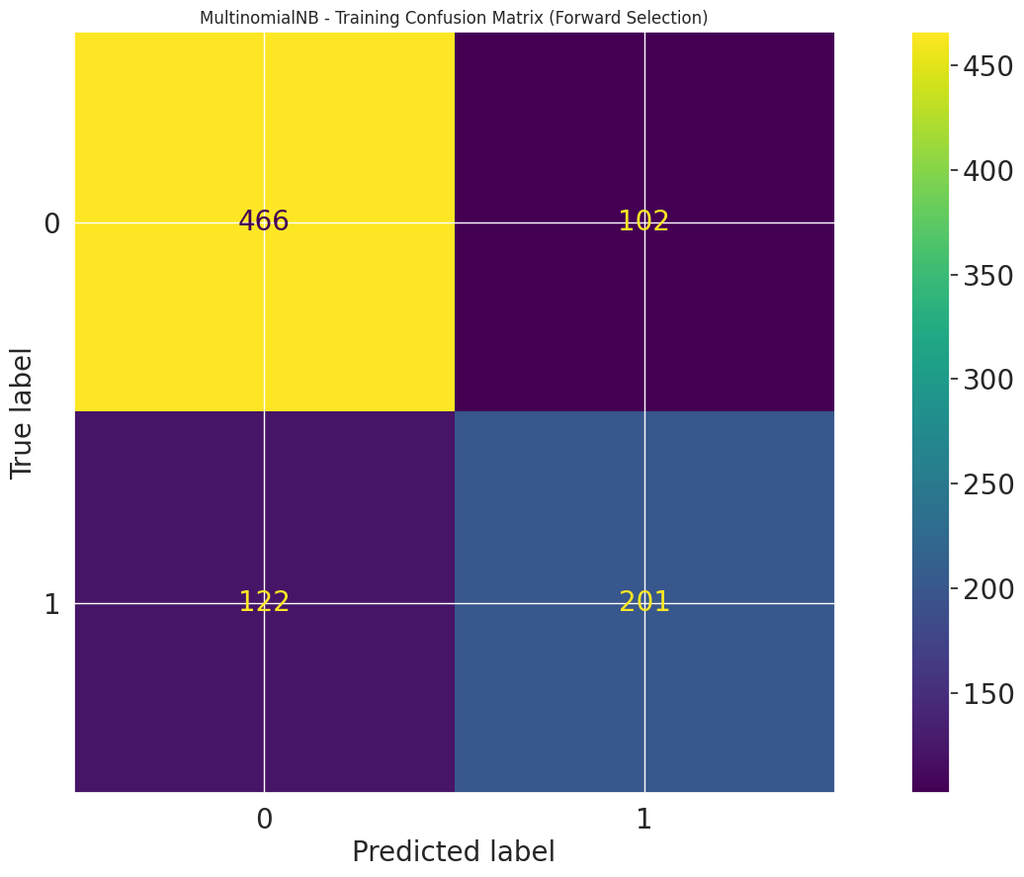

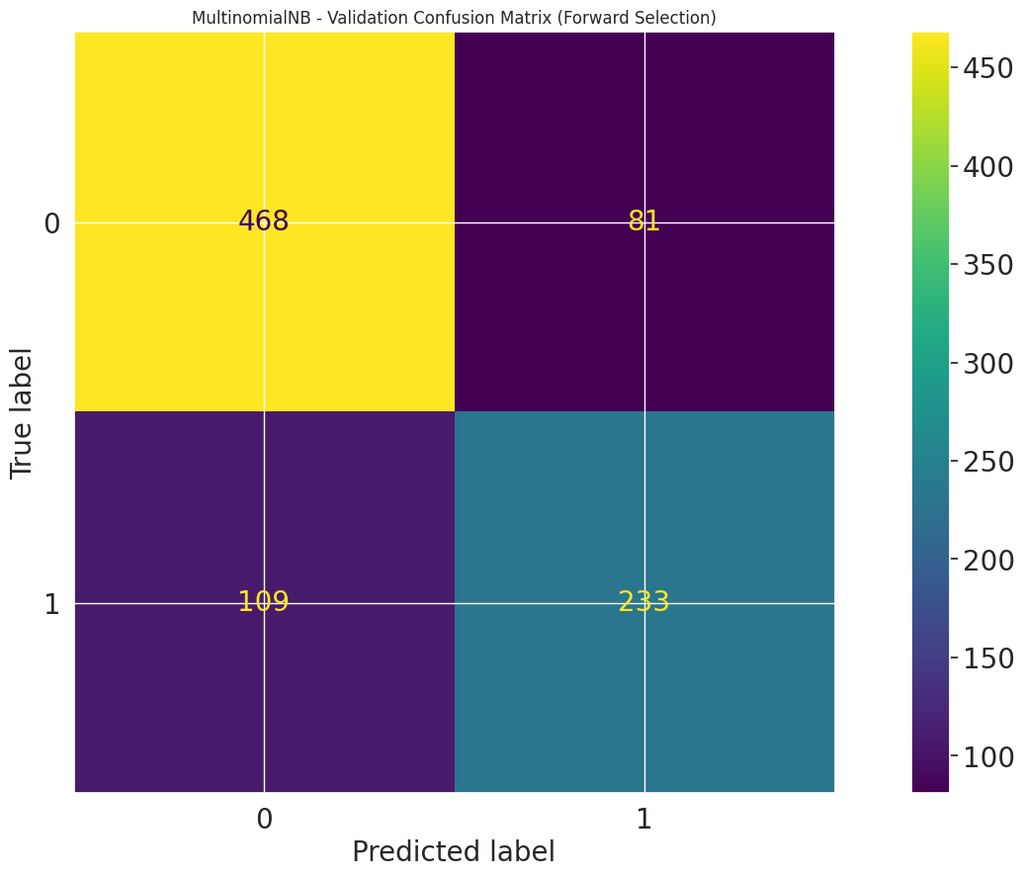

```
--------------------
Model: KNeighborsClassifier
--------------------
Running bootstrap iterations for KNeighborsClassifier with Forward Selection

Results for KNeighborsClassifier using Forward Selection:
Average Training Accuracy: 0.8138
Average Validation Accuracy: 0.8034
Average Training Loss (Log Loss): 0.4173
Average Validation Loss (Log Loss): 0.5144

Training KPIs for KNeighborsClassifier using Forward Selection:
Precision: 0.8486
Recall: 0.6086
F1 Score: 0.7088
Specificity: 0.9298
False Positive Rate: 0.0702

Validation KPIs for KNeighborsClassifier using Forward Selection:
Precision: 0.8300
Recall: 0.5994
F1 Score: 0.6961
Specificity: 0.9235
False Positive Rate: 0.0765
```

[12 more figures not shown]

```python
from sklearn.metrics import precision_score, recall_score, f1_score, confusion_matrix
import numpy as np
import matplotlib.pyplot as plt
from sklearn.metrics import log_loss, accuracy_score, ConfusionMatrixDisplay
from sklearn.ensemble import BaggingClassifier
from sklearn.naive_bayes import MultinomialNB
from sklearn.neighbors import KNeighborsClassifier
from sklearn.utils import resample
from sklearn.preprocessing import MinMaxScaler

# Feature selection methods
feature_selection_methods = ["Backward Elimination", "Forward Selection", "Hybrid Selection"]
dataframes = [X_selected_backword, X_selected_forward, X_selected_hybrid]

# Number of bootstrap iterations
n_iterations = 50

for feature_method, df, k in zip(feature_selection_methods, dataframes, optimal_k):
    print(f"\n{'=' * 40}\nFeature Selection Method: {feature_method}\n{'=' * 40}")
    X_NBC = MinMaxScaler().fit_transform(df)
    estimators = [
        ("MultinomialNB", MultinomialNB(), X_NBC),
        ("KNeighborsClassifier", KNeighborsClassifier(n_neighbors=k), df)
    ]
    for model_name, estimator, current_df in estimators:
        print(f"\n{'-' * 20}\nModel: {model_name}\n{'-' * 20}")
        print(f"Running bootstrap iterations for {model_name} with {feature_method}")

        # Accuracy and loss tracking
        train_accuracies = []
        val_accuracies = []
        train_losses = []
        val_losses = []

        # Bagging classifier
        bagging_model = BaggingClassifier(estimator=estimator,
                                          n_estimators=20, random_state=1,
                                          bootstrap=True)

        for iteration in range(n_iterations):
            # Resample for bootstrap
            X_train, t_train = resample(current_df, t, replace=True)
            X_val, t_val = resample(current_df, t, replace=False)

            # Train the model
            bagging_model.fit(X_train, t_train)

            # Compute accuracy for train and validation
            train_accuracy = accuracy_score(t_train, bagging_model.predict(X_train))
            train_accuracies.append(train_accuracy)

            val_accuracy = accuracy_score(t_val, bagging_model.predict(X_val))
            val_accuracies.append(val_accuracy)

            # Compute log loss for train and validation
            train_loss = log_loss(t_train, bagging_model.predict_proba(X_train))
            val_loss = log_loss(t_val, bagging_model.predict_proba(X_val))

            train_losses.append(train_loss)
            val_losses.append(val_loss)

        # Compute averages
        mean_train_accuracy = np.mean(train_accuracies)
        mean_val_accuracy = np.mean(val_accuracies)
        mean_train_loss = np.mean(train_losses)
        mean_val_loss = np.mean(val_losses)

        print(f"\nResults for {model_name} using {feature_method}:")
        print(f"Average Training Accuracy: {mean_train_accuracy:.4f}")
        print(f"Average Validation Accuracy: {mean_val_accuracy:.4f}")
        print(f"Average Training Loss (Log Loss): {mean_train_loss:.4f}")
        print(f"Average Validation Loss (Log Loss): {mean_val_loss:.4f}")

        # Calculate KPIs for the training and validation sets
        def calculate_kpis(true_labels, predictions):
            cm = confusion_matrix(true_labels, predictions)
            tp = cm[1, 1]  # True Positives
            tn = cm[0, 0]  # True Negatives
            fp = cm[0, 1]  # False Positives
            fn = cm[1, 0]  # False Negatives

            # Precision, Recall, F1-Score
            precision = precision_score(true_labels, predictions)
            recall = recall_score(true_labels, predictions)
            f1 = f1_score(true_labels, predictions)

            # Specificity and False Positive Rate
            specificity = tn / (tn + fp) if (tn + fp) != 0 else 0
            fpr = fp / (fp + tn) if (fp + tn) != 0 else 0

            return precision, recall, f1, specificity, fpr

        # Train KPIs
        train_predictions = bagging_model.predict(X_train)
        train_precision, train_recall, train_f1, train_specificity, train_fpr = calculate_kpis(t_train, train_predictions)
        print(f"\nTraining KPIs for {model_name} using {feature_method}:")
        print(f"Precision: {train_precision:.4f}")
        print(f"Recall: {train_recall:.4f}")
        print(f"F1 Score: {train_f1:.4f}")
        print(f"Specificity: {train_specificity:.4f}")
        print(f"False Positive Rate: {train_fpr:.4f}")

        # Validation KPIs
        val_predictions = bagging_model.predict(X_val)
        val_precision, val_recall, val_f1, val_specificity, val_fpr = calculate_kpis(t_val, val_predictions)
        print(f"\nValidation KPIs for {model_name} using {feature_method}:")
        print(f"Precision: {val_precision:.4f}")
        print(f"Recall: {val_recall:.4f}")
        print(f"F1 Score: {val_f1:.4f}")
        print(f"Specificity: {val_specificity:.4f}")
        print(f"False Positive Rate: {val_fpr:.4f}")

        # Plot training vs validation accuracy
        plt.figure(figsize=(10, 5))
        plt.plot(train_accuracies, label="Training Accuracy")
        plt.plot(val_accuracies, label="Validation Accuracy")
        plt.xlabel('Bootstrap Iterations')
        plt.ylabel('Accuracy')
        plt.legend()
        plt.title(f'{model_name} - Training vs Validation Accuracy ({feature_method})')
        plt.show()

        # Plot training vs validation loss
        plt.figure(figsize=(10, 5))
        plt.plot(train_losses, label="Training Loss")
        plt.plot(val_losses, label="Validation Loss")
        plt.xlabel('Bootstrap Iterations')
        plt.ylabel('Loss')
        plt.legend()
        plt.title(f'{model_name} - Training vs Validation Loss ({feature_method})')
        plt.show()

        # Confusion matrices
        train_cm = confusion_matrix(t_train, train_predictions)
        ConfusionMatrixDisplay(confusion_matrix=train_cm).plot()
        plt.title(f'{model_name} - Training Confusion Matrix ({feature_method})')
        plt.show()

        val_cm = confusion_matrix(t_val, val_predictions)
        ConfusionMatrixDisplay(confusion_matrix=val_cm).plot()
        plt.title(f'{model_name} - Validation Confusion Matrix ({feature_method})')
        plt.show()
```

**Here’s a breakdown of the output:**

### Feature Selection Methods:

tested three feature selection methods: **Backward Elimination**, **Forward Selection**, and **Hybrid Selection**. For each method, evaluated two models: **MultinomialNB** (Naive Bayes) and **KNeighborsClassifier** (KNN). The output provides several performance metrics for both models across different bootstrap iterations.

### Summary:

**For the test: KNeighborsClassifier with Hybrid Selection**

**summary for each model:**

For **KNN**, the performance heavily relies on the notion of local similarity and the distribution of data in the feature space. If the dataset has noisy features, irrelevant features, or an uneven class distribution, the nearest neighbors might not accurately represent the true relationship between the data points. Furthermore, if the feature scaling is inconsistent or the dataset is high-dimensional, the "curse of dimensionality" can degrade the model's performance, making distances between points less meaningful and reducing the model's ability to correctly classify samples.

For **NBC**, the model assumes that features are conditionally independent given the class label. This "naive" assumption often does not hold in real-world datasets, where features may exhibit complex correlations. Additionally, NBC works best with categorical data or data that can be discretized meaningfully. If your features are continuous and their distributions deviate significantly from the assumed multinomial or Gaussian distribution (depending on the variant), the model's probability estimates become less reliable. These mismatches can lead to poor generalization on the validation set and high log error.

# RFECV VS RFE in LogisticRegression

```python
from sklearn.model_selection import cross_val_score

# Logistic Regression with RFECV selected features
X_rfecv = X_encoded[[ 'Embarked_C', 'Embarked_Q', 'Embarked_S', 'Sex_female', 'Sex_male' ,'Pclass',
 'Age', 'SibSp', 'Fare']]
lr_rfecv = LogisticRegression(random_state=1)
score_rfecv = cross_val_score(lr_rfecv, X_rfecv, t, cv=5, scoring='accuracy')
print(f"RFECV Model Accuracy: {score_rfecv.mean()}")

# Logistic Regression with RFE selected features
X_rfe = X_encoded[['Sex_female', 'Parch', 'Sex_male']]
lr_rfe = LogisticRegression(random_state=1)
score_rfe = cross_val_score(lr_rfe, X_rfe, t, cv=5, scoring='accuracy')
print(f"RFE Model Accuracy: {score_rfe.mean()}")
```

```
RFECV Model Accuracy: 0.7901324461741259
RFE Model Accuracy: 0.7867365513778168
```

In first, We choose to work with the features of RFECV.

```python
# Get the selected feature names from the RFECV selector
selected_features = selector.get_feature_names_out()

# Keep only the columns that are in the selected features list
X_encoded = X_encoded[selected_features]
test_df_encoded = test_df_encoded[selected_features]
```

# Regularization

Laso, Ridge and Elastic Regularization on Logistic Regression

High-Variance could be decresed using Regularizations. With regularization, we can control the size of the model weights and thus reduce the variance. We control the size of the model weights by adding a negative term to the loss function. This term is called a penalty to high weights.

We have learned about three regularization techniques:

1. L1 (also called Lasso).
2. L2 (also called Ridge).
3. Elastic Net (a combination of Lasso and Ridge).

```python
from sklearn.linear_model import LogisticRegression
from sklearn.model_selection import cross_val_score
from sklearn.pipeline import make_pipeline
from sklearn.preprocessing import StandardScaler

# Logistic Regression with Lasso (L1) regularization
lr_lasso_cls = LogisticRegression(penalty='l1', solver='liblinear', random_state=1)

# Logistic Regression with Ridge (L2) regularization
lr_ridge_cls = LogisticRegression(penalty='l2', solver='liblinear', random_state=1)

# Logistic Regression with ElasticNet regularization
lr_elastic_cls = LogisticRegression(penalty='elasticnet', solver='saga', l1_ratio=0.5, random_state=1)

print("Accuracy score:")

# Cross-validation for Lasso regularization
lasso_score = cross_val_score(make_pipeline(StandardScaler(), lr_lasso_cls), X_encoded, t, cv=15).mean()
print(f'sgd_lasso: {lasso_score}')

# Cross-validation for Ridge regularization
ridge_score = cross_val_score(make_pipeline(StandardScaler(), lr_ridge_cls), X_encoded, t, cv=15).mean()
print(f'sgd_ridge: {ridge_score}')

# Cross-validation for ElasticNet regularization
elastic_score = cross_val_score(make_pipeline(StandardScaler(), lr_elastic_cls), X_encoded, t, cv=15).mean()
print(f'sgd_elastic: {elastic_score}')
```

```
Accuracy score:
sgd_lasso: 0.7934839924670433
sgd_ridge: 0.7935028248587571
sgd_elastic: 0.7946327683615819
```

The accuracy scores for the three Logistic Regression models are:

1. **Lasso (L1)**: 79.35%
2. **Ridge (L2)**: 79.35%
3. **ElasticNet**: 79.46%

We choose: **ElasticNet** outperforms the other two by a small margin. All three regularizations perform similarly, with **ElasticNet** slightly better, suggesting it combines the strengths of both Lasso and Ridge regularizations for this dataset.

# Spliting the train dataframe

```python
X_train, X_val, t_train, t_val =\
train_test_split(X_encoded, t, test_size=0.2, random_state=1)
```

**review of the columns**

```python
print(X_train.columns)
print(X_val.columns)
```

```
Index(['Embarked_C', 'Embarked_Q', 'Embarked_S', 'Sex_female', 'Sex_male',
       'Pclass', 'Age', 'SibSp', 'Fare'],
      dtype='object')
Index(['Embarked_C', 'Embarked_Q', 'Embarked_S', 'Sex_female', 'Sex_male',
       'Pclass', 'Age', 'SibSp', 'Fare'],
      dtype='object')
```

```python
# calculate cm for train and val
from sklearn.metrics import confusion_matrix, ConfusionMatrixDisplay
from sklearn.pipeline import make_pipeline

oe = OrdinalEncoder(handle_unknown='use_encoded_value', unknown_value=-1).fit(X_train)

model_pipe = make_pipeline(
    oe,
    StandardScaler(),
    LogisticRegression(penalty='elasticnet', solver='saga', random_state=1, l1_ratio=0.5)  # Set l1_ratio
).fit(X_train, t_train)

y_train = model_pipe.predict(X_train)
y_val = model_pipe.predict(X_val)
```

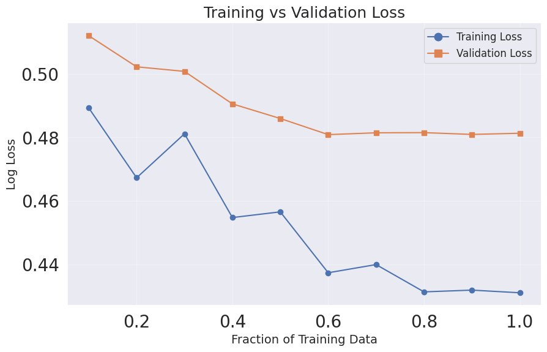

```python
from sklearn.metrics import accuracy_score, precision_score, recall_score, f1_score, confusion_matrix, log_loss
import seaborn as sns
import matplotlib.pyplot as plt
from sklearn.linear_model import LogisticRegression
import numpy as np

# Initialize Logistic Regression
logreg = LogisticRegression(max_iter=1000, random_state=1)

# Lists to store training and validation losses
train_losses = []
val_losses = []
training_sizes = np.linspace(0.1, 1.0, 10)  # Incremental training sizes

# Train model incrementally and calculate log loss
for size in training_sizes:
    # Sample a fraction of the training data
    X_train_sampled, t_train_sampled = X_train[:int(size * len(X_train))], t_train[:int(size * len(t_train))]

    # Train the model
    logreg.fit(X_train_sampled, t_train_sampled)

    # Predict probabilities
    t_pred_train_proba = logreg.predict_proba(X_train_sampled)
    t_pred_val_proba = logreg.predict_proba(X_val)

    # Calculate log loss for training and validation
    train_loss = log_loss(t_train_sampled, t_pred_train_proba)
    val_loss = log_loss(t_val, t_pred_val_proba)

    # Append losses
    train_losses.append(train_loss)
    val_losses.append(val_loss)

# Plot validation loss vs training loss
plt.figure(figsize=(10, 6))
plt.plot(training_sizes, train_losses, label='Training Loss', marker='o')
plt.plot(training_sizes, val_losses, label='Validation Loss', marker='s')
plt.title("Training vs Validation Loss", fontsize=18)
plt.xlabel("Fraction of Training Data", fontsize=14)
plt.ylabel("Log Loss", fontsize=14)
plt.legend(fontsize=12)
plt.grid(alpha=0.3)
plt.show()
```

The results show a typical pattern where the log loss on the training data decreases as the fraction of training data increases, which is expected because the model has more data to learn from. However, the log loss on the validation set stabilizes around 0.48, indicating that the model's ability to generalize does not improve significantly with more training data beyond a certain point. This suggests that the model might be overfitting the training data as it becomes more specialized, while its performance on the validation set remains relatively constant.

### **Normalized [0,1] confusion matrix**

```python
cm_train = confusion_matrix(t_train, y_train)
cm_val = confusion_matrix(t_val, y_val)

cm_train_normalized = confusion_matrix(t_train, y_train, normalize='true')
cm_val_normalized = confusion_matrix(t_val, y_val, normalize='true')

cm_train_normalized_manually = cm_train / cm_train.sum(1)
cm_val_normalized_manually = cm_val / cm_val.sum(1)

print('cm_train_normalized_manually:\n', cm_train_normalized_manually)
print()
print('cm_val_normalized_manually:\n', cm_val_normalized_manually)
print()

print('cm_train_normalized:\n', cm_train_normalized)
print()
print('cm_val_normalized:\n', cm_val_normalized)
```

```
cm_train_normalized_manually:
 [[0.8510158  0.24535316]
 [0.1738149  0.71375465]]

cm_val_normalized_manually:
 [[0.8490566  0.21917808]
 [0.20754717 0.69863014]]

cm_train_normalized:
 [[0.8510158  0.1489842 ]
 [0.28624535 0.71375465]]

cm_val_normalized:
 [[0.8490566  0.1509434 ]
 [0.30136986 0.69863014]]
```

```python
# show tn, fp, fn and tp for train and val
tn_train, fp_train, fn_train, tp_train = cm_train.ravel()
tn_val, fp_val, fn_val, tp_val = cm_val.ravel()

print(f'Train: TN {tn_train:4}, FP {fp_train:4}, FN {fn_train:4}, TP {tp_train:4}')
print(f'Val:   TN {tn_val:4}, FP {fp_val:4}, FN {fn_val:4}, TP {tp_val:4}')
```

```
Train: TN  377, FP   66, FN   77, TP  192
Val:   TN   90, FP   16, FN   22, TP   51
```

The confusion matrix breakdown for training and validation shows:

### **Training (Train):**

- **True Negatives (TN)**: 377 cases correctly predicted as negative.
- **False Positives (FP)**: 66 cases incorrectly predicted as positive.
- **False Negatives (FN)**: 77 cases incorrectly predicted as negative.
- **True Positives (TP)**: 192 cases correctly predicted as positive.

### **Validation (Val):**

- **True Negatives (TN)**: 90 cases correctly predicted as negative.
- **False Positives (FP)**: 16 cases incorrectly predicted as positive.
- **False Negatives (FN)**: 22 cases incorrectly predicted as negative.
- **True Positives (TP)**: 51 cases correctly predicted as positive.

**Visualization**

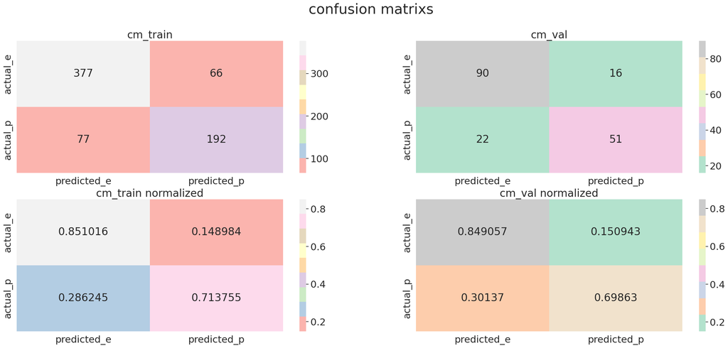

```python
# lot confusion matrix of train and val as heatmaps in seaborn
cm_train_df = pd.DataFrame(cm_train, index=['actual_e', 'actual_p'],
                           columns=['predicted_e', 'predicted_p'])
cm_val_df = pd.DataFrame(cm_val, index=['actual_e', 'actual_p'],
                         columns=['predicted_e', 'predicted_p'])
cm_train_normalized_df = pd.DataFrame(cm_train_normalized,
                                 index=['actual_e', 'actual_p'],
                                 columns=['predicted_e', 'predicted_p'])

cm_val_normalized_df = pd.DataFrame(cm_val_normalized,
                                 index=['actual_e', 'actual_p'],
                                 columns=['predicted_e', 'predicted_p'])


sns.set(font_scale=2)
fig = plt.figure(figsize = (30,12))
fig.suptitle('confusion matrixs',fontsize=32)
ax1 = fig.add_subplot(221)
sns.heatmap(cm_train_df, annot=True, cmap=plt.cm.Pastel1, fmt='g')
ax1.title.set_text("cm_train")


ax2 = fig.add_subplot(222)
sns.heatmap(cm_val_df, annot=True, cmap=plt.cm.Pastel2, fmt='g')
ax2.title.set_text("cm_val")

ax3 = fig.add_subplot(223)
sns.heatmap(cm_train_normalized_df, annot=True, cmap=plt.cm.Pastel1, fmt='g')
ax3.title.set_text("cm_train normalized")


ax4 = fig.add_subplot(224)
sns.heatmap(cm_val_normalized_df, annot=True, cmap=plt.cm.Pastel2, fmt='g')
ax4.title.set_text("cm_val normalized")
plt.show()
```

```python
# calculate precision, recall, specificity, fpr and accuracy
def precision(cm):
    tn, fp, fn, tp = cm.ravel()
    return tp/(tp+fp)

def recall(cm):
    tn, fp, fn, tp = cm.ravel()
    return tp/(tp+fn)

def specificity(cm):
    tn, fp, fn, tp = cm.ravel()
    return tn/(tn+fp)

def fpr(cm):
    tn, fp, fn, tp = cm.ravel()
    return fp/(fp+tn)

def accuracy(cm):
    tn, fp, fn, tp = cm.ravel()
    return (tp+tn)/(tp+tn+fp+fn)

print(f'Train: precision {precision(cm_train):.2f}, recall {recall(cm_train):.2f}, specificity {specificity(cm_train):.2f}, fpr {fpr(cm_train):.2f}, accuracy {accuracy(cm_train):.2f}')
print(f'Val:   precision {precision(cm_val):.2f}, recall {recall(cm_val):.2f}, specificity {specificity(cm_val):.2f}, fpr {fpr(cm_val):.2f}, accuracy {accuracy(cm_val):.2f}')
```

```
Train: precision 0.74, recall 0.71, specificity 0.85, fpr 0.15, accuracy 0.80
Val:   precision 0.76, recall 0.70, specificity 0.85, fpr 0.15, accuracy 0.79
```

The metrics for training and validation data indicate the following:

### **Training (Train):**

- **Precision (0.74)**: 74% of predicted positives are correct.
- **Recall (0.71)**: 71% of actual positives are identified correctly.
- **Specificity (0.85)**: 85% of actual negatives are identified correctly.
- **FPR (0.15)**: 15% of actual negatives are misclassified as positive.
- **Accuracy (0.80)**: Overall, 80% of predictions are correct.

### **Validation (Val):**

- **Precision (0.76)**: Slightly higher than training, showing better positive prediction accuracy.
- **Recall (0.70)**: Slightly lower than training, meaning fewer positives are identified.
- **Specificity (0.85)**: Matches training, showing consistency in identifying negatives.
- **FPR (0.15)**: Matches training, indicating stable false positive performance.
- **Accuracy (0.79)**: Slightly lower than training, reflecting typical generalization loss.

Overall, the model performs consistently across train and validation sets, with balanced precision, recall, and specificity.

```python
# calculate f1 and balanced accuracy
def f1(cm):
    precision_calc = precision(cm)
    recall_calc = recall(cm)
    return (2*precision_calc*recall_calc)/(precision_calc+recall_calc)

def balanced_accuracy(cm):
    recall_calc = recall(cm)
    specificity_calc = specificity(cm)
    return (recall_calc+specificity_calc)/2

print(f'Train: f1 {f1(cm_train):.2f}, balanced_accuracy {balanced_accuracy(cm_train):.2f}')
print(f'Val:   f1 {f1(cm_val):.2f}, balanced_accuracy {balanced_accuracy(cm_val):.2f}')
```

```
Train: f1 0.73, balanced_accuracy 0.78
Val:   f1 0.73, balanced_accuracy 0.77
```

### **Training (Train):**

- **F1 Score (0.73)**: Balanced measure of precision and recall, indicating good performance in predicting positives.
- **Balanced Accuracy (0.78)**: Average of recall (0.71) and specificity (0.85), showing overall balance in identifying both classes.

### **Validation (Val):**

- **F1 Score (0.73)**: Matches training, indicating consistent performance in predicting positives.
- **Balanced Accuracy (0.77)**: Slightly lower than training, reflecting minor generalization loss.

Both metrics demonstrate stable performance between training and validation datasets.

```python
from sklearn.pipeline import Pipeline
from sklearn.preprocessing import StandardScaler
from sklearn.linear_model import LinearRegression
import pandas as pd
X_train_KNN=X_train.copy()
print(X_train.columns)
print(test_df_encoded.columns)

pipeline_model = Pipeline([
    ('scaler', StandardScaler()),
    ('classifier', LogisticRegression(penalty='elasticnet', solver='saga', random_state=1, l1_ratio=0.5))
])


# Train the pipeline
pipeline_model.fit(X_train, t_train)

# Predict on test data
# X_test = test_encoded[high_corr_features]  # Ensure these variables are defined
predictions = pipeline_model.predict(test_df_encoded)

# Create the submission file
output = pd.DataFrame({'PassengerId': id_test,  # Ensure test_ID is defined
                       'Survived': predictions})

output.to_csv('submission.csv', index=False)

print("Saved the predictions to a .csv file")
```

```
Index(['Embarked_C', 'Embarked_Q', 'Embarked_S', 'Sex_female', 'Sex_male',
       'Pclass', 'Age', 'SibSp', 'Fare'],
      dtype='object')
Index(['Embarked_C', 'Embarked_Q', 'Embarked_S', 'Sex_female', 'Sex_male',
       'Pclass', 'Age', 'SibSp', 'Fare'],
      dtype='object')
Saved the predictions to a .csv file
```

# Competition: Part one and Part Two

In this work We were required to use Logistic Regression, therefore we dont want to change the model, we want to try and change the features.

With that features we scored in the competition: 0.77511

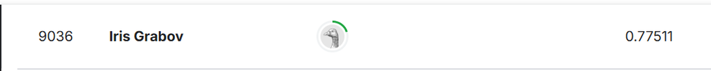

Lets try the fetures that RFE selected:

```python
# Get the selected feature names from the RFE selector
selected_features = selector_RFE.get_feature_names_out()

# Keep only the columns that are in the selected features list
X_train = X_train[selected_features]
test_df_encoded = test_df_encoded[selected_features]


print(X_train.columns)
print(test_df_encoded.columns)

pipeline_model = Pipeline([
    ('scaler', StandardScaler()),
    ('classifier', LogisticRegression(penalty='elasticnet', solver='saga', random_state=1, l1_ratio=0.5))
])


# Train the pipeline
pipeline_model.fit(X_train, t_train)

# Predict on test data
# X_test = test_encoded[high_corr_features]  # Ensure these variables are defined
predictions = pipeline_model.predict(test_df_encoded)

# Create the submission file
output = pd.DataFrame({'PassengerId': id_test,  # Ensure test_ID is defined
                       'Survived': predictions})

output.to_csv('submission.csv', index=False)

print("Saved the predictions to a .csv file")
```

```
Index(['Sex_female', 'Sex_male', 'Pclass'], dtype='object')
Index(['Sex_female', 'Sex_male', 'Pclass'], dtype='object')
Saved the predictions to a .csv file
```

We achive 0.76555, this is a lower score, as we expected

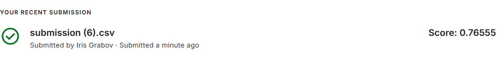

# Competition Part 2: KNN + Boostrap + Hybraid Feature Selection

```python
from sklearn.pipeline import Pipeline
from sklearn.preprocessing import StandardScaler
from sklearn.neighbors import KNeighborsClassifier
from sklearn.utils import resample
import pandas as pd
import numpy as np

# Assuming `X_selected_hybrid` contains the selected features after feature selection
selected_features = X_selected_hybrid.columns

# Ensure both training and test datasets contain the same selected features
X_train_KNN = X_train_KNN[selected_features]
test_df_encoded_KNN = test_df_encoded_KNN[selected_features]



# Set up KNN model
k = 5  # Adjust the number of neighbors for KNN
knn_model = KNeighborsClassifier(n_neighbors=k)

# Initialize an empty list to store predictions from bootstrap iterations
predictions_list = []

# Number of bootstrap iterations
n_iterations = 50

# Train the model using bootstrap sampling and make predictions
for i in range(n_iterations):
    # Resample the training data with replacement (Bootstrap sampling)
    X_train_KNN_resampled, t_train_resampled = resample(X_train_KNN, t_train, replace=True, random_state=i)

    # Standardize the features using StandardScaler
    scaler = StandardScaler()
    X_train_KNN_scaled = scaler.fit_transform(X_train_KNN_resampled)
    test_scaled = scaler.transform(test_df_encoded_KNN)  # Apply the same transformation to the test data

    # Train the KNN model
    knn_model.fit(X_train_KNN_scaled, t_train_resampled)

    # Make predictions on the test set
    predictions = knn_model.predict(test_scaled)
    predictions_list.append(predictions)

# Calculate the average prediction (for ensemble effect)
final_predictions = np.mean(predictions_list, axis=0)  # Average predictions from all iterations
final_predictions = np.round(final_predictions).astype(int)  # Convert to binary class (0 or 1)

# Create the submission file
output = pd.DataFrame({'PassengerId': id_test,  # Ensure `id_test` contains PassengerId from the test set
                       'Survived': final_predictions})

output.to_csv('submission_knn_bootstrap.csv', index=False)

print("Saved the predictions to a .csv file using KNN with bootstrap sampling.")
```

```
Saved the predictions to a .csv file using KNN with bootstrap sampling.
```

# The Score:

We achive our best place with: KNN+boostrap+Hybrid Selection.

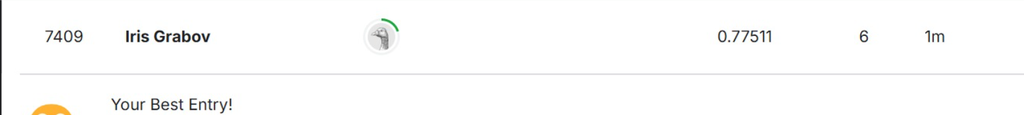

We proud of that.

### **Summary of the Work**

#### **1. Data Investigation and Preprocessing**

- **Data Analysis:** Initial exploration included understanding the dataset structure, examining missing values, and identifying categorical and numerical features.
- **Feature Encoding:**
  - Categorical variables like `Embarked` and `Sex` were one-hot encoded.
- **Handling Missing Values:** Imputation techniques were applied for missing data.

#### **2. Feature Selection**

using RFE and RFECV

Forward Feature Selection Backward Feature Selection Hybrid Feature Selection

- Selected features included:
  - Categorical: `Embarked_C`, `Embarked_Q`, `Embarked_S`, `Sex_female`, `Sex_male`, `Pclass`.
  - Numerical: `Age`, `SibSp`, `Fare`.
- Dropped irrelevant or redundant features after analyzing correlations and importance.

#### **3. Data Splitting and Cross-Validation**

- **Data Splitting:**
  - Data was split into training (80%) and validation (20%) sets using `train_test_split`.
- **Cross-Validation:** Incremental training sizes were used to evaluate the model's robustness and learning curve, comparing training and validation log loss.

Bootstrapping

#### **5. Model Training and Evaluation**

- **Pipeline:** A pipeline with ordinal encoding, feature scaling, and logistic regression was created for efficient modeling.
- **Metrics Evaluated:**
  - Precision, recall, F1 score, specificity, false positive rate (FPR), accuracy, balanced accuracy.
  - Training and validation confusion matrices were computed and analyzed.

KNN NBC LDA- undersdanding and investigating

#### **7. Competition Outcome**

- The model achieved a **real test score of 0.77511** in the competition, indicating strong predictive performance and ranking competitively.
- Place: 7409

#### **Key Takeaways**

- Effective preprocessing, feature engineering, and model tuning led to a well-performing logistic regression model.
- Elastic net regularization and feature scaling ensured robustness and reduced overfitting.
- Consistent validation results highlighted the model's ability to generalize to unseen data.

# List of References:

We use the notebooks from the practice:

- notebook from practice 4
- notebook from practice 5
- notebook from practice 6
- notebook from practice 7
- notebook from practice 8
- notebook from practice 9